# Chapter 8 Metabarcoding selected filtering (t3_p10)

```r
load("resources/metagenomics/data_filtered.Rdata")
load("resources/amplicon/selected_filtering.Rdata")
species_color <- c("#e5bd5b", "#6b7398", "#76b183")
```

## 8.1 Taxonomy

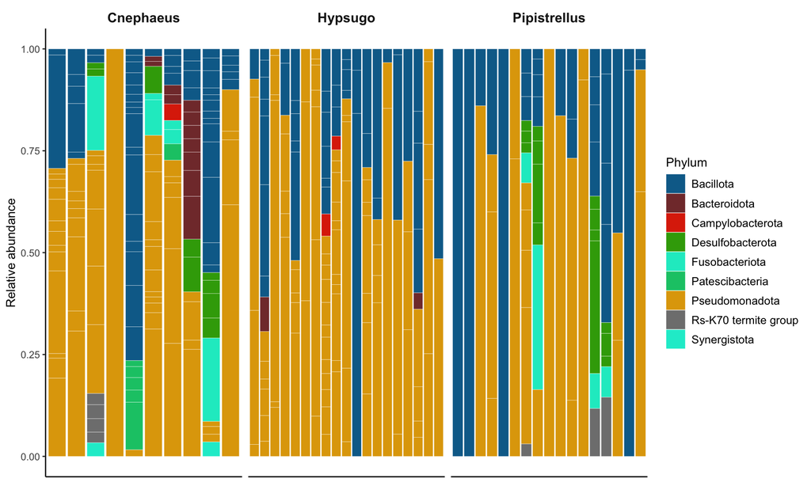

```r
genome_counts_filt_amplicon %>%
  mutate_at(vars(-genome),  ~ . / sum(.)) %>%
  pivot_longer(-genome, names_to = "sample", values_to = "count") %>%
  left_join(., genome_metadata_amplicon, by = join_by(genome == genome)) %>%
  left_join(., sample_metadata_amplicon, by = join_by(sample == sample)) %>%
  filter(count > 0) %>% #filter 0 counts
  ggplot(., aes(
    x = sample,
    y = count,
    fill = phylum,
    group = phylum
  )) +
  geom_bar(stat = "identity",
           colour = "white",
           linewidth = 0.1) +
  scale_fill_manual(values = phylum_colors) +
  facet_nested( ~ factor(
    Species,
    labels = c("Eb" = "Cnephaeus", "Ha" = "Hypsugo", "Pk" = "Pipistrellus")
  ), scales = "free") +
  guides(fill = guide_legend(ncol = 1)) +
  theme(
    axis.text.x = element_blank(),
    axis.ticks.x = element_blank(),
    axis.title.x = element_blank(),
    panel.background = element_blank(),
    panel.border = element_blank(),
    panel.grid.major = element_blank(),
    panel.grid.minor = element_blank(),
    legend.text = element_text(size = 10),
    strip.background = element_rect(fill = "white"),
    strip.text = element_text(
      size = 12,
      lineheight = 0.6,
      face = "bold"
    ),
    axis.line = element_line(
      linewidth = 0.5,
      linetype = "solid",
      colour = "black"
    )
  ) +
  labs(fill = "Phylum", y = "Relative abundance", x = "Samples")+
  guides(fill = guide_legend(ncol = 1))
```

**Grouping low-abundance bacteria**

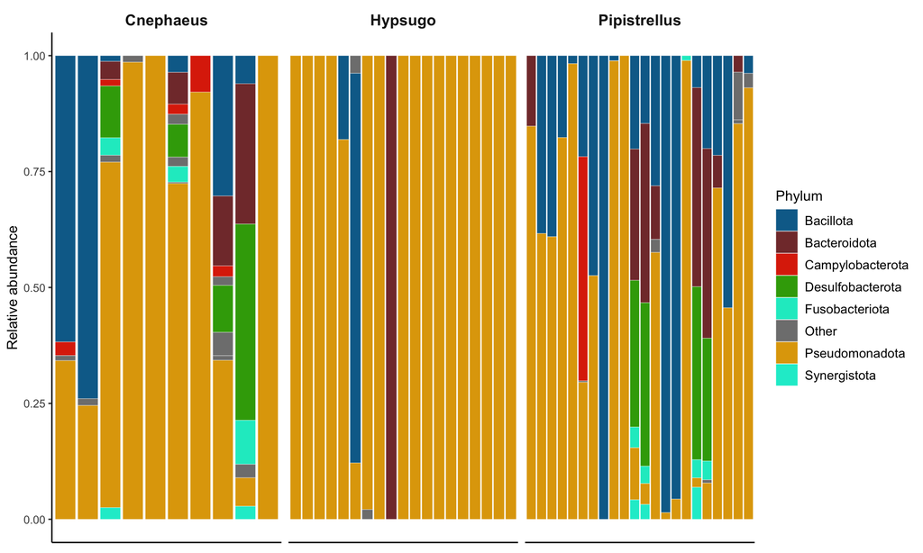

```r
p1 <- genome_counts_filt %>%
  mutate_at(vars(-genome), ~ . / sum(.)) %>%
  pivot_longer(-genome, names_to = "sample", values_to = "count") %>%
  left_join(genome_metadata, by = join_by(genome == genome)) %>%
  left_join(sample_metadata, by = join_by(sample == sample)) %>%
  filter(count > 0) %>%
group_by(sample, phylum) %>%
  mutate(total_abundance = sum(count)) %>%
  ungroup() %>%
  mutate(phylum = if_else(total_abundance < 0.01, "Other", phylum)) %>%
  group_by(sample, phylum, Species) %>%
  summarise(count = sum(count), .groups = "drop") %>%
   ggplot(aes(
    x = sample,
    y = count,
    fill = phylum,
    group = phylum
  )) +
  geom_bar(stat = "identity",
           colour = "white",
           linewidth = 0.1) +
  scale_fill_manual(values = c(phylum_colors, "Other" = "grey50"),
                    drop = FALSE)+
  facet_nested(~ factor(
    Species,
    labels = c("Eb" = "Cnephaeus", "Ha" = "Hypsugo", "Pk" = "Pipistrellus")
  ), scales = "free") +
  guides(fill = guide_legend(ncol = 1)) +
  theme(
    axis.text.x = element_blank(),
    axis.ticks.x = element_blank(),
    axis.title.x = element_blank(),
    panel.background = element_blank(),
    panel.border = element_blank(),
    panel.grid.major = element_blank(),
    panel.grid.minor = element_blank(),
    legend.text = element_text(size = 10),
    strip.background = element_rect(fill = "white"),
    strip.text = element_text(
      size = 12,
      lineheight = 0.6,
      face = "bold"
    ),
    axis.line = element_line(
      linewidth = 0.5,
      linetype = "solid",
      colour = "black"
    )
  ) +
  labs(fill = "Phylum", y = "Relative abundance", x = "Samples")+
  guides(fill = guide_legend(ncol = 1))

#ggsave("community_plot_grouped_selected.pdf", plot = p1, width = 12, height = 6)
p1
```

**Phylum relative abundances**

```r
phylum_summary <- genome_counts_filt_amplicon %>%
  mutate_at(vars(-genome),~./sum(.)) %>%
  pivot_longer(-genome, names_to = "sample", values_to = "count") %>%
  left_join(sample_metadata_amplicon, by = join_by(sample == sample)) %>%
  left_join(genome_metadata_amplicon, by = join_by(genome == genome)) %>%
  group_by(sample,phylum,Species) %>%
  summarise(relabun=sum(count))
```

```r
phylum_summary %>%
  group_by(phylum) %>%
  summarise(
    Total_mean = mean(relabun * 100, na.rm = T),
    Total_sd = sd(relabun * 100, na.rm = T),
    Eb_mean = mean(relabun[Species == "Eb"] * 100, na.rm = T),
    Eb_sd = sd(relabun[Species == "Eb"] * 100, na.rm = T),
    Ha_mean = mean(relabun[Species == "Ha"] * 100, na.rm = T),
    Ha_sd = sd(relabun[Species == "Ha"] * 100, na.rm = T),
    Pk_mean = mean(relabun[Species == "Pk"] * 100, na.rm = T),
    Pk_sd = sd(relabun[Species == "Pk"] * 100, na.rm = T)
  ) %>%
  mutate(
    Total = str_c(round(Total_mean, 3), "±", round(Total_sd, 3)),
    Cnephaeus = str_c(round(Eb_mean, 3), "±", round(Eb_sd, 3)),
    Hypsugo = str_c(round(Ha_mean, 3), "±", round(Ha_sd, 3)),
    Pipistrellus = str_c(round(Pk_mean, 3), "±", round(Pk_sd, 3))
  ) %>%
  arrange(-Eb_mean) %>%
  dplyr::select(phylum,
                Total,
                Cnephaeus,
                Hypsugo,
                Pipistrellus) %>%
  tt()
```

| phylum | Total | Cnephaeus | Hypsugo | Pipistrellus |
| --- | --- | --- | --- | --- |
| Pseudomonadota | 59.82±35.675 | 59.189±33.515 | 69.095±28.3 | 49.826±42.873 |
| Bacillota | 31.817±31.618 | 22.436±25.315 | 29.786±27.371 | 39.606±38.523 |
| Fusobacteriota | 2.473±6.759 | 5.475±8.105 | 0±0 | 3.471±8.808 |
| Bacteroidota | 1.165±5.195 | 4.116±10.646 | 0.655±2.098 | 0±0 |
| Desulfobacterota | 2.83±8.205 | 3.887±6.035 | 0±0 | 5.371±12.321 |
| Patescibacteria | 0.563±3.268 | 2.591±6.897 | 0±0 | 0±0 |
| Rs-K70 termite group | 0.9±3.222 | 1.208±3.82 | 0±0 | 1.726±4.386 |
| Synergistota | 0.15±0.713 | 0.691±1.459 | 0±0 | 0±0 |
| Campylobacterota | 0.28±1.094 | 0.406±1.283 | 0.464±1.431 | 0±0 |

```r
bats = c("Eb", "Pk", "Ha")

total_asvs <- data.frame(
  Bat = character(),
  ASVs = numeric(),
  Phylum = numeric(),
  Family = numeric(),
  Genus = numeric()
)

preabs_table <- genome_counts_filt_amplicon %>%
  mutate(across(-genome, ~ . / sum(.))) %>%
  column_to_rownames("genome") %>%
  mutate(across(everything(), ~ as.integer(. > 0))) %>%
  t() %>%
  as.data.frame() %>%
  rownames_to_column("sample") %>%
  left_join(sample_metadata_amplicon[c("sample", "Species")], by = "sample") %>%
  group_by(Species) %>%
  summarize(across(-sample, sum), .groups = "drop") %>%
  column_to_rownames("Species") %>%
  t() %>%
  as.data.frame() %>%
  rownames_to_column("genome")  %>%
  left_join(genome_metadata_amplicon, by = join_by("genome" == "genome")) %>%
  filter(domain=="Bacteria")

phylum <- preabs_table %>%
  distinct(phylum)

family <- preabs_table %>%
  distinct(phylum, class, order, family)

genus <- preabs_table %>%
  distinct(phylum, class, order, family, genus)

total_asvs <- rbind(
  total_asvs,
  data.frame(
    Bat = "Total",
    ASVs = nrow(preabs_table),
    Phylum = nrow(phylum),
    Family = nrow(family),
    Genus = nrow(genus)
  )
)

for (bat in bats) {
  number <- preabs_table %>%
    select({{bat}}) %>%
    filter(. >= 1)

  phylum <- preabs_table %>%
    select({{bat}}, phylum) %>%
    filter(!!sym(bat) >= 1) %>%
    distinct(phylum)

  family <- preabs_table %>%
    select({{bat}}, phylum, class, order, family) %>%
    filter(!!sym(bat) >= 1) %>%
    distinct(phylum, class, order, family)

  genus <- preabs_table %>%
    select({{bat}}, phylum, class, order, family, genus) %>%
    filter(!!sym(bat) >= 1) %>%
    distinct(phylum, class, order, family, genus)

  total_asvs <- rbind(
    total_asvs,
    data.frame(
      Bat = bat,
      ASVs = nrow(number),
      Phylum = nrow(phylum),
      Family = nrow(family),
      Genus = nrow(genus)
    )
  )
}
```

```r
bats = c("Eb", "Pk", "Ha")

no_annotation <- data.frame(Bat = character(),
                            No_genus = numeric(),
                            No_species = numeric())

preabs_table <- genome_counts_filt_amplicon %>%
  mutate(across(-genome, ~ . / sum(.))) %>%
  column_to_rownames("genome") %>%
  mutate(across(everything(), ~ as.integer(. > 0))) %>%
  t() %>%
  as.data.frame() %>%
  rownames_to_column("sample") %>%
  left_join(sample_metadata_amplicon[c("sample", "Species")], by = "sample") %>%
  group_by(Species) %>%
  summarize(across(-sample, sum), .groups = "drop") %>%
  column_to_rownames("Species") %>%
  t() %>%
  as.data.frame() %>%
  rownames_to_column("genome")  %>%
  left_join(genome_metadata_amplicon, by = join_by("genome" == "genome")) %>%
  filter(domain=="Bacteria")

genus <- preabs_table  %>%
  filter(is.na(genus))

species <- preabs_table  %>%
  filter(is.na(species))

no_annotation <- rbind(no_annotation,
                       data.frame(
                         Bat = "Total",
                         No_genus = nrow(genus),
                         No_species = nrow(species)
                       ))

for (bat in bats) {
  number <- preabs_table %>%
    select({{bat}}) %>%
    filter(. >= 1)

  genus <- preabs_table %>%
    select({{bat}}, phylum, class, order, family, genus) %>%
    filter(!!sym(bat) >= 1) %>%
  filter(is.na(genus))

  species <- preabs_table %>%
    filter(!!sym(bat) >= 1) %>%
  filter(is.na(species))

  no_annotation <- rbind(no_annotation,
                         data.frame(
                           Bat = bat,
                           No_genus = nrow(genus),
                           No_species = nrow(species)
                         ))
}
```

**Total percentage of ASVs without genus-level annotation**

```r
nongenera <- genome_metadata_amplicon %>%
  filter(domain=="Bacteria") %>%
  filter(is.na(genus)) %>%
  summarize(ASV_nogenera = n()) %>%
  pull()
nasvs <- total_asvs %>%
  filter(Bat == "Total") %>%
  select(ASVs) %>%
  pull()
perct <- nongenera * 100 / nasvs
cat(perct)
```

```
22.42424
```

**Percentage of ASVs without genus-level annotation by phylum**

```r
total_asv_phylum <- genome_metadata_amplicon %>%
  filter(domain=="Bacteria") %>%
  group_by(phylum) %>%
  summarize(Total_ASVs = n())
genome_metadata_amplicon %>%
  filter(is.na(genus)) %>%
  group_by(phylum) %>%
  summarize(ASVs_nogenus = n()) %>%
  left_join(total_asv_phylum, by = join_by(phylum == phylum)) %>%
  mutate(Percentage_nogenus = 100 * ASVs_nogenus / Total_ASVs) %>%
  tt()
```

| phylum | ASVs_nogenus | Total_ASVs | Percentage_nogenus |
| --- | --- | --- | --- |
| Bacillota | 12 | 57 | 21.052632 |
| Bacteroidota | 1 | 12 | 8.333333 |
| Patescibacteria | 4 | 6 | 66.666667 |
| Pseudomonadota | 16 | 71 | 22.535211 |
| Rs-K70 termite group | 4 | 4 | 100.000000 |

**Number of bacterial species**

```r
genome_metadata_amplicon %>%
  filter(domain == "Bacteria")%>%
  dplyr::select(species) %>%
  unique() %>%
  drop_na() %>%
  pull() %>%
  length() %>%
  cat()
```

```
10
```

**Total percentage of ASVs without species-level annotation**

```r
nonspecies <- genome_metadata_amplicon %>%
  filter(domain=="Bacteria") %>%
  filter(is.na(species)) %>%
  summarize(ASV_nospecies = n()) %>%
  pull()
perct <- nonspecies * 100 / nasvs
cat(perct)
```

```
90.90909
```

**ASVs without species-level annotation**

```r
total_mag_phylum <- genome_metadata_amplicon %>%
  filter(domain=="Bacteria") %>%
  group_by(phylum) %>%
  summarize(ASVs_total = n())

genome_metadata_amplicon %>%
  filter(domain=="Bacteria") %>%
  filter(is.na(species)) %>%
  group_by(phylum) %>%
  summarize(ASVs_nospecies = n()) %>%
  left_join(total_mag_phylum, by = join_by(phylum == phylum)) %>%
  mutate(Species_annotated = ASVs_total - ASVs_nospecies) %>%
  mutate(Percentage_nospecies = 100 * ASVs_nospecies / ASVs_total) %>%
  mutate(Percentage_species = 100 - 100 * ASVs_nospecies / ASVs_total) %>%
  tt()
```

| phylum | ASVs_nospecies | ASVs_total | Species_annotated | Percentage_nospecies | Percentage_species |
| --- | --- | --- | --- | --- | --- |
| Bacillota | 53 | 57 | 4 | 92.98246 | 7.017544 |
| Bacteroidota | 10 | 12 | 2 | 83.33333 | 16.666667 |
| Campylobacterota | 2 | 2 | 0 | 100.00000 | 0.000000 |
| Desulfobacterota | 8 | 8 | 0 | 100.00000 | 0.000000 |
| Fusobacteriota | 3 | 4 | 1 | 75.00000 | 25.000000 |
| Patescibacteria | 6 | 6 | 0 | 100.00000 | 0.000000 |
| Pseudomonadota | 63 | 71 | 8 | 88.73239 | 11.267606 |
| Rs-K70 termite group | 4 | 4 | 0 | 100.00000 | 0.000000 |
| Synergistota | 1 | 1 | 0 | 100.00000 | 0.000000 |

### 8.1.1 Summary table

```r
bats = c("Eb", "Pk", "Ha")

single_sp <- data.frame(Bat = character(), Single_species = numeric())

bacteria <- genome_metadata_amplicon %>%
  filter(domain=="Bacteria")

table_upset_analysis <- genome_counts_filt_amplicon %>%
  mutate(across(-genome, ~ . / sum(.))) %>%
  filter(genome %in% bacteria$genome) %>%
  column_to_rownames("genome") %>%
  mutate(across(everything(), ~ as.integer(. > 0))) %>%
  t() %>%
  as.data.frame() %>%
  rownames_to_column("sample") %>%
  left_join(sample_metadata_amplicon[c("sample", "Species")], by = "sample") %>%
  group_by(Species) %>%
  summarize(across(-sample, sum), .groups = "drop") %>%
  column_to_rownames("Species") %>%
  mutate(across(everything(), ~ as.integer(. > 0))) %>%
  t() %>%
  as.data.frame() %>%
  rownames_to_column("sample")

unique_all <- table_upset_analysis %>%
  filter(rowSums(across(Eb:Pk)) == 1)

single_sp <- rbind(single_sp, data.frame(Bat = "Total",
                                         Single_species = nrow(unique_all)))

for (bat in bats) {
  unique <- table_upset_analysis %>%
    filter(rowSums(across(Eb:Pk)) == 1) %>%
    column_to_rownames(., "sample") %>%
    select(bat) %>%
    filter(. > 0) %>%
    nrow()
  single_sp <- rbind(single_sp, data.frame(Bat = bat, Single_species = unique))
}
```

```r
single_ind <- data.frame(Bat = character(), Single_individual = numeric())

freq_table <- genome_counts_filt_amplicon %>%
  mutate(across(-genome, ~ . / sum(.))) %>%
  filter(genome %in% bacteria$genome) %>%
  column_to_rownames("genome") %>%
  mutate(across(everything(), ~ as.integer(. > 0))) %>%
  t() %>%
  as.data.frame() %>%
  rownames_to_column("sample") %>%
  left_join(sample_metadata_amplicon[c("sample", "Species")], by = "sample") %>%
  group_by(Species) %>%
  summarize(across(-sample, sum), .groups = "drop") %>%
  column_to_rownames("Species") %>%
  t() %>%
  as.data.frame() %>%
  rownames_to_column("asv")

singleton_filt <- freq_table %>%
  rowwise() %>%
  mutate(row_sum = sum(c_across(-asv))) %>%
  filter(row_sum == 1) %>%
  column_to_rownames(var = "asv")  %>%
  filter(row_sum == 1)

single_ind <- rbind(single_ind, data.frame(
  Bat = "Total",
  Single_individual = nrow(singleton_filt)
))

for (bat in bats) {
  singleton_filt <- freq_table %>%
    rowwise() %>%
    mutate(row_sum = sum(c_across(-asv))) %>%
    filter(row_sum == 1) %>%
    column_to_rownames(var = "asv")  %>%
    select(bat) %>%
    filter(. == 1)

  single_ind <- rbind(single_ind, data.frame(
    Bat = bat,
    Single_individual = nrow(singleton_filt)
  ))
}
```

```r
summary_table_ampli <- total_asvs %>%
  left_join(., no_annotation, by = "Bat") %>%
  left_join(., single_ind, by = "Bat") %>%
  left_join(., single_sp, by = "Bat") %>%
  mutate(Bat = recode(Bat,
                      Eb = "Cnephaeus bottae",
                      Ha = "Hypsugo ariel",
                      Pk = "Pipistrellus kuhlii"))
summary_table_ampli %>%
  tt()
```

| Bat | ASVs | Phylum | Family | Genus | No_genus | No_species | Single_individual | Single_species |
| --- | --- | --- | --- | --- | --- | --- | --- | --- |
| Total | 165 | 9 | 51 | 71 | 37 | 150 | 96 | 141 |
| Cnephaeus bottae | 130 | 9 | 40 | 55 | 29 | 118 | 96 | 108 |
| Pipistrellus kuhlii | 19 | 5 | 11 | 12 | 2 | 17 | 0 | 1 |
| Hypsugo ariel | 45 | 4 | 25 | 28 | 9 | 42 | 0 | 32 |

```r
total_asv <- nrow(genome_metadata_amplicon)
summary_table_ampli %>%
  select(-Phylum,-Family, -Genus) %>%
  rowwise() %>%
  mutate(ASV_perc=round(ASVs*100/total_asv, 2))%>%
  mutate(No_genus_perc=round(No_genus*100/ASVs, 2))%>%
  mutate(No_species_perc=round(No_species*100/ASVs, 2)) %>%
  mutate(Single_individual_perc=round(Single_individual*100/ASVs, 2))%>%
  mutate(Single_species_perc=round(Single_species*100/ASVs, 2)) %>%
  mutate(Single_individual_per_unique=round(Single_individual*100/Single_species, 2)) %>%
  select(1,7:12) %>% tt()
```

| Bat | ASV_perc | No_genus_perc | No_species_perc | Single_individual_perc | Single_species_perc | Single_individual_per_unique |
| --- | --- | --- | --- | --- | --- | --- |
| Total | 100.00 | 22.42 | 90.91 | 58.18 | 85.45 | 68.09 |
| Cnephaeus bottae | 78.79 | 22.31 | 90.77 | 73.85 | 83.08 | 88.89 |
| Pipistrellus kuhlii | 11.52 | 10.53 | 89.47 | 0.00 | 5.26 | 0.00 |
| Hypsugo ariel | 27.27 | 20.00 | 93.33 | 0.00 | 71.11 | 0.00 |

**Shared phyla**

```r
meta_phylum <- genome_metadata %>%
  distinct(domain,phylum)

genome_metadata_amplicon %>%
  distinct(domain,phylum) %>%
  filter(phylum %in% meta_phylum$phylum)
```

```
    domain           phylum
1 Bacteria   Pseudomonadota
2 Bacteria   Fusobacteriota
3 Bacteria        Bacillota
4 Bacteria Desulfobacterota
5 Bacteria     Synergistota
6 Bacteria     Bacteroidota
7 Bacteria Campylobacterota
```

**Only in metagenomic data**

```r
ampli_phylum <- genome_metadata_amplicon %>%
  distinct(domain,phylum)

genome_metadata %>%
  distinct(domain,phylum) %>%
  filter(!phylum %in% genome_metadata_amplicon$phylum)
```

```
# A tibble: 6 × 2
  domain   phylum
  <chr>    <chr>
1 Bacteria Elusimicrobiota
2 Bacteria Deferribacterota
3 Bacteria Planctomycetota
4 Bacteria Spirochaetota
5 Bacteria Actinomycetota
6 Bacteria Cyanobacteriota
```

**Only in metabarcoding selected data**

```r
genome_metadata_amplicon %>%
  distinct(domain,phylum) %>%
  filter(!phylum %in% meta_phylum$phylum)
```

```
    domain               phylum
1 Bacteria Rs-K70 termite group
2 Bacteria      Patescibacteria
```

### 8.1.2 Differences at family level

**Number of families in metagenomic data**

```r
load("resources/metagenomics/data_filtered.Rdata")
```

```r
cat(genome_metadata %>%
      distinct(domain, phylum, family) %>%
      count() %>%
      pull())
```

```
56
```

**Number of families in metabarcoding selected data**

```r
cat(genome_metadata_amplicon %>%
      distinct(domain, phylum, family) %>%
      count() %>%
      pull())
```

```
49
```

**Shared families**

```r
meta_family <- genome_metadata %>%
  distinct(domain,phylum, family)

genome_metadata_amplicon %>%
  distinct(domain,phylum, family) %>%
  filter(family %in% meta_family$family)
```

```
     domain           phylum              family
1  Bacteria   Pseudomonadota Diplorickettsiaceae
2  Bacteria   Pseudomonadota        Vibrionaceae
3  Bacteria   Pseudomonadota  Enterobacteriaceae
4  Bacteria   Fusobacteriota    Leptotrichiaceae
5  Bacteria        Bacillota     Enterococcaceae
6  Bacteria   Pseudomonadota      Morganellaceae
7  Bacteria   Pseudomonadota     Pasteurellaceae
8  Bacteria   Pseudomonadota      Aeromonadaceae
9  Bacteria        Bacillota    Mycoplasmataceae
10 Bacteria        Bacillota    Streptococcaceae
11 Bacteria   Pseudomonadota      Rickettsiaceae
12 Bacteria Desulfobacterota Desulfovibrionaceae
13 Bacteria        Bacillota      Clostridiaceae
14 Bacteria        Bacillota     Lachnospiraceae
15 Bacteria     Synergistota      Synergistaceae
16 Bacteria   Pseudomonadota    Burkholderiaceae
17 Bacteria        Bacillota     Ruminococcaceae
18 Bacteria   Fusobacteriota    Fusobacteriaceae
19 Bacteria   Pseudomonadota      Halomonadaceae
20 Bacteria     Bacteroidota       Weeksellaceae
21 Bacteria   Pseudomonadota      Rhodocyclaceae
22 Bacteria   Pseudomonadota       Neisseriaceae
23 Bacteria        Bacillota Erysipelotrichaceae
24 Bacteria Campylobacterota   Helicobacteraceae
25 Bacteria        Bacillota Christensenellaceae
26 Bacteria     Bacteroidota      Bacteroidaceae
27 Bacteria Campylobacterota  Campylobacteraceae
28 Bacteria     Bacteroidota   Dysgonomonadaceae
29 Bacteria   Pseudomonadota    Acetobacteraceae
```

**Only in metagenomic data**

```r
ampli_family <- genome_metadata_amplicon %>%
  distinct(domain,phylum,family)

genome_metadata %>%
  distinct(domain,phylum,family) %>%
  filter(!family %in% ampli_family$family)
```

```
# A tibble: 27 × 3
   domain   phylum           family
   <chr>    <chr>            <chr>
 1 Bacteria Pseudomonadota   ""
 2 Bacteria Elusimicrobiota  "Elusimicrobiaceae"
 3 Bacteria Bacillota        "Metamycoplasmataceae"
 4 Bacteria Bacillota        "Acutalibacteraceae"
 5 Bacteria Pseudomonadota   "CAG-239"
 6 Bacteria Bacillota        ""
 7 Bacteria Desulfobacterota "Adiutricaceae"
 8 Bacteria Bacteroidota     "Tannerellaceae"
 9 Bacteria Deferribacterota "Mucispirillaceae"
10 Bacteria Planctomycetota  "SZUA-567"
# ℹ 17 more rows
```

**Only in metabarcoding selected data**

```r
genome_metadata_amplicon %>%
  distinct(domain,phylum,family) %>%
  filter(!family %in% meta_family$family)
```

```
     domain               phylum                             family
1  Bacteria       Pseudomonadota                       Yersiniaceae
2  Bacteria            Bacillota                        Bacillaceae
3  Bacteria Rs-K70 termite group                               <NA>
4  Bacteria            Bacillota                      Aerococcaceae
5  Bacteria       Pseudomonadota                   Pseudomonadaceae
6  Bacteria       Pseudomonadota                               <NA>
7  Bacteria            Bacillota                 Acidaminococcaceae
8  Bacteria            Bacillota                   Lactobacillaceae
9  Bacteria       Pseudomonadota                   Aquaspirillaceae
10 Bacteria       Pseudomonadota                         Hafniaceae
11 Bacteria            Bacillota                               <NA>
12 Bacteria       Pseudomonadota                     Comamonadaceae
13 Bacteria      Patescibacteria                               <NA>
14 Bacteria            Bacillota              Peptostreptococcaceae
15 Bacteria            Bacillota                     Eubacteriaceae
16 Bacteria      Patescibacteria                 Saccharimonadaceae
17 Bacteria            Bacillota [Clostridium] methylpentosum group
18 Bacteria            Bacillota          Erysipelatoclostridiaceae
19 Bacteria            Bacillota                      Vagococcaceae
20 Bacteria            Bacillota                   Anaerovoracaceae
```

### 8.1.3 Differences in top ASVs and MAGs

Top 20 MAGs

```r
genome_counts_filt %>%
  mutate(across(-genome, ~ . / sum(.))) %>%
  mutate(total = rowSums(across(-genome))) %>%
  arrange(desc(total)) %>%
  slice_head(n = 20) %>%
  select(genome, total) %>%
  left_join(genome_metadata[1:8])
```

```
      genome      total   domain         phylum               class              order               family             genus        species
1  HA_bin.16 10.1429255 Bacteria Pseudomonadota Gammaproteobacteria Diplorickettsiales  Diplorickettsiaceae Aquirickettsiella
2  PK_bin.10  3.4725989 Bacteria      Bacillota             Bacilli    Mycoplasmatales    Mycoplasmoidaceae      Malacoplasma
3  EH_bin.20  3.0940365 Bacteria Pseudomonadota Gammaproteobacteria   Enterobacterales         Vibrionaceae            Vibrio       cholerae
4   HA_bin.8  2.4545179 Bacteria Pseudomonadota Alphaproteobacteria      Rickettsiales       Rickettsiaceae        Rickettsia
5  PK_bin.26  1.9706785 Bacteria Pseudomonadota Gammaproteobacteria   Enterobacterales   Enterobacteriaceae          Serratia     ureilytica
6   HA_bin.7  1.9293752 Bacteria Pseudomonadota Gammaproteobacteria       Chromatiales        Chromatiaceae
7  PK_bin.12  1.2830141 Bacteria Pseudomonadota Alphaproteobacteria      Rickettsiales       Rickettsiaceae        Rickettsia tillamookensis
8  PK_bin.46  1.1521884 Bacteria   Bacteroidota         Bacteroidia   Flavobacteriales        Weeksellaceae         Apibacter       raozihei
9  PK_bin.53  0.9584216 Bacteria Pseudomonadota Alphaproteobacteria      Rickettsiales       Rickettsiaceae        Rickettsia         bellii
10 PK_bin.52  0.9404985 Bacteria Pseudomonadota Gammaproteobacteria   Enterobacterales   Enterobacteriaceae        Klebsiella     pneumoniae
11 PK_bin.64  0.9119555 Bacteria Pseudomonadota Gammaproteobacteria   Enterobacterales       Morganellaceae        Morganella       morganii
12  EH_bin.5  0.8747411 Bacteria      Bacillota             Bacilli    Mycoplasmatales     Mycoplasmataceae       Spiroplasma     phoeniceum
13 HA_bin.19  0.8484409 Bacteria      Bacillota             Bacilli    Mycoplasmatales     Mycoplasmataceae    Edwardiiplasma
14  PK_bin.5  0.8435610 Bacteria Pseudomonadota Gammaproteobacteria   Enterobacterales      Pasteurellaceae       Pasteurella         oralis
15 PK_bin.72  0.8277429 Bacteria      Bacillota             Bacilli    Lactobacillales      Enterococcaceae      Enterococcus       faecalis
16 PK_bin.68  0.7829460 Bacteria Pseudomonadota Gammaproteobacteria   Enterobacterales   Enterobacteriaceae           Proteus       cibarius
17  HA_bin.3  0.7433329 Bacteria Pseudomonadota Gammaproteobacteria    Burkholderiales     Burkholderiaceae
18  HA_bin.2  0.7297240 Bacteria Pseudomonadota Alphaproteobacteria    Acetobacterales     Acetobacteraceae
19 PK_bin.22  0.7287690 Bacteria      Bacillota             Bacilli    Mycoplasmatales Metamycoplasmataceae            UBA710
20  EH_bin.1  0.6409658 Bacteria Pseudomonadota Gammaproteobacteria   Enterobacterales       Aeromonadaceae         Aeromonas        veronii
```

Top 20 ASVs

```r
genome_counts_filt_amplicon %>%
  mutate(across(-genome, ~ . / sum(.))) %>%
  mutate(total = rowSums(across(-genome))) %>%
  arrange(desc(total)) %>%
  slice_head(n = 20) %>%
  select(genome, total) %>%
  left_join(genome_metadata_amplicon)
```

```
   genome     total   domain         phylum               class              order              family                  genus    species
1   ASV_4 4.3518819 Bacteria Pseudomonadota Gammaproteobacteria   Enterobacterales  Enterobacteriaceae           Enterobacter       <NA>
2  ASV_11 3.9768492 Bacteria      Bacillota             Bacilli         Bacillales         Bacillaceae               Bacillus       <NA>
3   ASV_2 2.7289641 Bacteria Pseudomonadota Gammaproteobacteria   Enterobacterales        Yersiniaceae               Serratia       <NA>
4   ASV_6 2.5898514 Bacteria      Bacillota             Bacilli    Lactobacillales     Enterococcaceae           Enterococcus       <NA>
5   ASV_8 2.5493553 Bacteria Pseudomonadota Gammaproteobacteria   Enterobacterales     Pasteurellaceae      Vespertiliibacter       <NA>
6   ASV_3 2.0513046 Bacteria Pseudomonadota Gammaproteobacteria   Enterobacterales        Vibrionaceae                 Vibrio       <NA>
7  ASV_14 1.8643868 Bacteria Pseudomonadota Gammaproteobacteria   Enterobacterales        Yersiniaceae               Serratia       <NA>
8  ASV_12 1.7938123 Bacteria      Bacillota             Bacilli         Bacillales         Bacillaceae               Bacillus       <NA>
9   ASV_1 1.7444575 Bacteria Pseudomonadota Gammaproteobacteria Diplorickettsiales Diplorickettsiaceae          Rickettsiella       <NA>
10 ASV_10 1.6173961 Bacteria Pseudomonadota Gammaproteobacteria   Enterobacterales      Aeromonadaceae              Aeromonas       <NA>
11 ASV_40 1.3502123 Bacteria Pseudomonadota Gammaproteobacteria   Enterobacterales  Enterobacteriaceae                   <NA>       <NA>
12  ASV_5 0.9772474 Bacteria Fusobacteriota       Fusobacteriia    Fusobacteriales    Leptotrichiaceae             Sebaldella termitidis
13 ASV_24 0.9751893 Bacteria Pseudomonadota Alphaproteobacteria      Rickettsiales      Rickettsiaceae             Rickettsia       <NA>
14 ASV_44 0.9235237 Bacteria Pseudomonadota Gammaproteobacteria   Enterobacterales      Morganellaceae             Morganella   morganii
15 ASV_90 0.8531774 Bacteria      Bacillota          Clostridia      Clostridiales      Clostridiaceae Candidatus Arthromitus       <NA>
16 ASV_17 0.6277963 Bacteria Pseudomonadota Gammaproteobacteria   Enterobacterales     Pasteurellaceae                   <NA>       <NA>
17 ASV_57 0.6125441 Bacteria Pseudomonadota Gammaproteobacteria               <NA>                <NA>                   <NA>       <NA>
18 ASV_74 0.5883388 Bacteria Pseudomonadota Alphaproteobacteria      Rickettsiales      Rickettsiaceae             Rickettsia       <NA>
19 ASV_34 0.5197320 Bacteria      Bacillota          Clostridia     Lachnospirales     Lachnospiraceae      Lachnoclostridium       <NA>
20 ASV_46 0.5138308 Bacteria      Bacillota          Clostridia     Lachnospirales     Lachnospiraceae      Lachnoclostridium       <NA>
```

Phylum level

```r
topMAG <- genome_counts_filt %>%
  mutate(across(-genome, ~ . / sum(.))) %>%
  left_join(genome_metadata[c(1, 3, 6, 7)], by="genome") %>%
  select(-genome) %>%
  group_by(phylum) %>%
  summarize(across(where(is.numeric), sum), .groups = "drop") %>%
  mutate(total_mag = rowSums(across(where(is.numeric)))) %>%
  select(total_mag, phylum) %>%
  arrange(desc(total_mag))%>%
  slice_head(n = 10)
```

```r
topASV <- genome_counts_filt_amplicon %>%
  mutate(across(-genome, ~ . / sum(.))) %>%
  left_join(genome_metadata_amplicon, by="genome") %>%
  select(-genome) %>%
  group_by(phylum) %>%
  summarize(across(where(is.numeric), sum), .groups = "drop") %>%
  mutate(total_asv = rowSums(across(where(is.numeric)))) %>%
  select(total_asv, phylum) %>%
  arrange(desc(total_asv)) %>%
  slice_head(n = 10)

table <- full_join(topMAG,topASV, by="phylum") %>%
    mutate(ASV = replace_na(total_asv, 0)) %>%
    mutate(MAG = replace_na(total_mag, 0)) %>%
  select(-total_asv, -total_mag) %>%
  pivot_longer(cols = c(MAG, ASV),
               names_to = "source",
               values_to = "abundance")
```

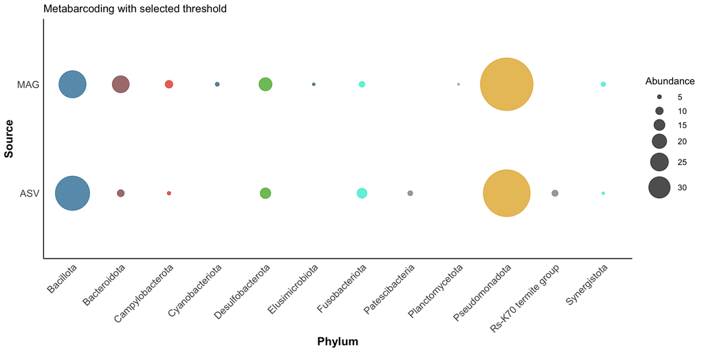

```r
ggplot(table, aes(x = source, y = phylum, size = abundance, color = phylum)) +
  geom_point(alpha = 0.7) +
  scale_size_continuous(
    name = "Abundance",
    range = c(0.01, 30),   # 0 ensures no bubble at abundance = 0
    breaks = seq(0, 35, by = 5),   # Controls legend labels (your 0–5–10–...–30)
    limits = c(0.01, NA)   # keep full range of values
  )  +
    scale_color_manual(values = phylum_colors) +
    coord_flip()+
  theme_minimal()+
  theme(axis.text.x = element_text(angle = 45,hjust = 1, size=12),
        axis.text.y = element_text(size = 12),
        axis.title = element_text(size = 14, face = "bold"),
        panel.background = element_blank(),
        panel.grid.major = element_blank(),
        panel.grid.minor = element_blank(),
        axis.line = element_line(size = 0.5, linetype = "solid", colour = "black"),
        legend.text = element_text(size = 10),
        legend.title = element_text(size = 12))+
  labs(x = "Source", y = "Phylum",
    title = "Metabarcoding with selected threshold")+
  guides(color = "none", size = guide_legend(
      override.aes = list(size = c(2, 4, 6, 8, 10, 12)) # smaller bubbles in legend
    )
  )
```

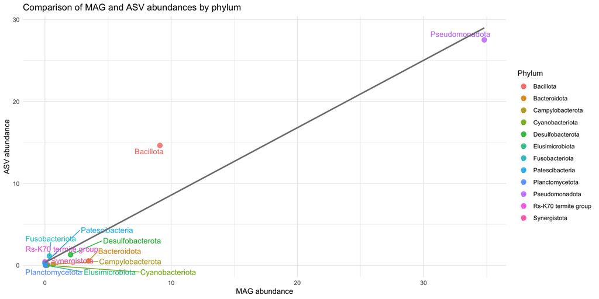

```r
full_join(topMAG,topASV, by="phylum") %>%
    mutate(ASV = replace_na(total_asv, 0)) %>%
    mutate(MAG = replace_na(total_mag, 0)) %>%
  ggplot(., aes(x = MAG, y = ASV, color = phylum, label = phylum)) +
  geom_point(size = 3, alpha = 0.8) +
  geom_text_repel(max.overlaps = 20) +
  geom_smooth(method = "lm", se = FALSE, color = "grey50") +
  labs(
    x = "MAG abundance",
    y = "ASV abundance",
    color = "Phylum",
    title = "Comparison of MAG and ASV abundances by phylum"
  ) +
  theme_minimal()
```

Family level

```r
topFMAG <- genome_counts_filt %>%
  mutate(across(-genome, ~ . / sum(.))) %>%
  left_join(genome_metadata[c(1:7)], by="genome") %>%
  mutate(
    class  = if_else(str_trim(class) == "", paste0(phylum, "_Unclassified"), class),
    order  = if_else(str_trim(order) == "",
                     if_else(str_detect(class, "Unclassified"), class, paste0(class, "_Unclassified")),
                     order),
    family = if_else(str_trim(family) == "",
                     if_else(str_detect(order, "Unclassified"), order, paste0(order, "_Unclassified")),
                     family),
    genus  = if_else(str_trim(genus) == "",
                     if_else(str_detect(family, "Unclassified"), family, paste0(family, "_Unclassified")),
                     genus)
  )%>%
  select(-genome) %>%
  group_by(phylum, family) %>%
  summarize(across(where(is.numeric), sum), .groups = "drop") %>%
  mutate(total_mag = rowSums(across(where(is.numeric)))) %>%
  select(total_mag, phylum, family) %>%
  arrange(desc(total_mag)) %>%
  slice_head(n = 20)
```

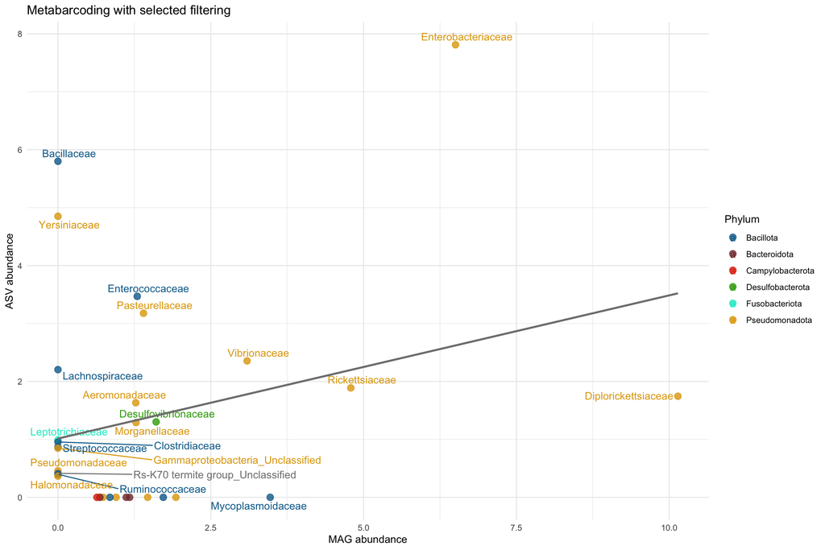

```r
full_join(topFMAG,topFASV, by="family") %>%
    mutate(ASV = replace_na(total_asv, 0)) %>%
    mutate(MAG = replace_na(total_mag, 0)) %>%
    mutate(phylum_mag = coalesce(phylum.x, phylum.y))%>%
  ggplot(., aes(x = MAG, y = ASV, color = phylum_mag, label = family)) +
  geom_point(size = 3, alpha = 0.8) +
  geom_text_repel(max.overlaps = 10) +
  geom_smooth(method = "lm", se = FALSE, color = "grey50") +
      scale_color_manual(values = phylum_colors) +
  labs(
    x = "MAG abundance",
    y = "ASV abundance",
    color = "Phylum",
    title = "Metabarcoding with selected filtering"
  ) +
  theme_minimal()
```

## 8.2 Alpha Diversity

### 8.2.1 ASV level

```r
richness <- genome_counts_filt_amplicon %>%
  column_to_rownames(var = "genome") %>%
  dplyr::select(where( ~ !all(. == 0))) %>%
  hilldiv(., q = 0) %>%
  t() %>%
  as.data.frame() %>%
  dplyr::rename(richness = 1) %>%
  rownames_to_column(var = "sample")

neutral <- genome_counts_filt_amplicon %>%
  column_to_rownames(var = "genome") %>%
  dplyr::select(where( ~ !all(. == 0))) %>%
  hilldiv(., q = 1) %>%
  t() %>%
  as.data.frame() %>%
  dplyr::rename(neutral = 1) %>%
  rownames_to_column(var = "sample")

metabarcoding_selected_alpha_div <- richness %>%
  full_join(neutral, by = join_by(sample == sample)) %>%
  mutate(method="Metabarcoding_selected")
```

**Correlation between diversity and estimate microbial fraction**

```r
fraction_ampli <- microbial_fraction %>%
  select(sample, estimated_microbial_fraction) %>%
  right_join(metabarcoding_selected_alpha_div, by="sample") %>%
  left_join(sample_metadata_amplicon, by="sample")

cor.test(fraction_ampli$estimated_microbial_fraction, fraction_ampli$richness, method = "spearman")
```

```
    Spearman's rank correlation rho

data:  fraction_ampli$estimated_microbial_fraction and fraction_ampli$richness
S = 12490, p-value = 0.9393
alternative hypothesis: true rho is not equal to 0
sample estimates:
        rho
-0.01210846
```

```r
cor.test(fraction_ampli$estimated_microbial_fraction, fraction_ampli$neutral, method = "spearman")
```

```
    Spearman's rank correlation rho

data:  fraction_ampli$estimated_microbial_fraction and fraction_ampli$neutral
S = 12808, p-value = 0.8119
alternative hypothesis: true rho is not equal to 0
sample estimates:
        rho
-0.03784748
```

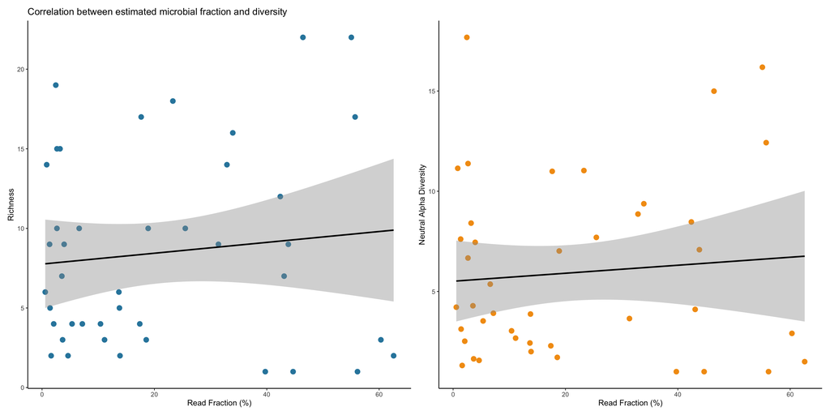

```r
p1_ampli <- ggplot(fraction_ampli, aes(x = estimated_microbial_fraction, y = richness)) +
  geom_point(size = 3, color = "#2E86AB") +
  geom_smooth(method = "lm", se = TRUE, color = "black") +
  theme_classic() +
  labs(x = "Read Fraction (%)", y = "Richness", title= "Correlation between estimated microbial fraction and diversity")

p2_ampli <- ggplot(fraction_ampli, aes(x = estimated_microbial_fraction, y = neutral)) +
  geom_point(size = 3, color = "#F39C12") +
  geom_smooth(method = "lm", se = TRUE, color = "black") +
  theme_classic() +
  labs(x = "Read Fraction (%)", y = "Neutral Alpha Diversity")

p1_ampli + p2_ampli
```

```r
richness %>%
  full_join(neutral, by = join_by(sample == sample))  %>%
  pivot_longer(-sample, names_to = "alpha", values_to = "value") %>%
  left_join(sample_metadata, by = join_by(sample == sample)) %>%
  group_by(alpha) %>%
  summarise(
    total_mean = mean(value, na.rm = T),
    total_sd = sd(value, na.rm = T),
    Eb_mean = mean(value[Species == "Eb"], na.rm = T),
    Eb_sd = sd(value[Species == "Eb"], na.rm = T),
    Ha_mean = mean(value[Species == "Ha"], na.rm = T),
    Ha_sd = sd(value[Species == "Ha"], na.rm = T),
    Pk_mean = mean(value[Species == "Pk"], na.rm = T),
    Pk_sd = sd(value[Species == "Pk"], na.rm = T)
  ) %>%
  mutate(
    Total = str_c(round(total_mean, 2), "±", round(total_sd, 2)),
    Cnephaeus = str_c(round(Eb_mean, 2), "±", round(Eb_sd, 2)),
    Hypsugo = str_c(round(Ha_mean, 2), "±", round(Ha_sd, 2)),
    Pipistrellus = str_c(round(Pk_mean, 2), "±", round(Pk_sd, 2))
  ) %>%
  arrange(-Eb_mean) %>%
  dplyr::select(alpha, Total, Cnephaeus, Pipistrellus, Hypsugo) %>%
  tt()
```

| alpha | Total | Cnephaeus | Pipistrellus | Hypsugo |
| --- | --- | --- | --- | --- |
| richness | 7.87±6.17 | 15.1±6.23 | 4.12±3.69 | 7.42±4.6 |
| neutral | 5.52±4.44 | 9.69±4.66 | 3.14±2.66 | 5.46±4.14 |

### 8.2.2 Different taxonomic level

```r
sample_metadata_amplicon <- sample_metadata_amplicon[c(1,9,10,13)] %>%
  mutate(sample = paste0(sample, "_ampli_selec")) %>%
  mutate(method="Metabarcoding_selected")

genome_metadata_amplicon <- genome_metadata_amplicon %>%
  mutate(
    class  = if_else(is.na(class), paste0(phylum, "_Unclassified"), class),
    order  = if_else(is.na(order),
                     if_else(str_detect(class, "Unclassified"), class, paste0(class, "_Unclassified")),
                     order),
    family = if_else(is.na(family),
                     if_else(str_detect(order, "Unclassified"), order, paste0(order, "_Unclassified")),
                     family),
    genus  = if_else(is.na(genus),
                     if_else(str_detect(family, "Unclassified"), family, paste0(family, "_Unclassified")),
                     genus)
  )

genome_tax_ampli <- genome_counts_filt_amplicon %>%
  column_to_rownames(., "genome")%>%
  rename_with(~ paste0(., "_ampli_selec")) %>%
  rownames_to_column(., "genome")%>%
  left_join(genome_metadata_amplicon, by = "genome")

family_level_agg_ampli <- genome_tax_ampli %>%
  select(-genome) %>%
  group_by(phylum, class, family) %>%
  summarise(across(where(is.numeric), \(x) sum(x, na.rm = TRUE)), .groups = "drop")%>%
    as.data.frame() %>%
  select(-c(phylum,class))

phylum_level_agg_ampli <- genome_tax_ampli %>%
  select(-genome) %>%
  group_by(phylum) %>%
  summarise(across(where(is.numeric), \(x) sum(x, na.rm = TRUE)), .groups = "drop")%>%
    as.data.frame()
```

#### 8.2.2.1 Family level

```r
richness_f_ampli <- family_level_agg_ampli %>%
  column_to_rownames(var = "family") %>%
  dplyr::select(where( ~ !all(. == 0))) %>%
  hilldiv(., q = 0) %>%
  t() %>%
  as.data.frame() %>%
  dplyr::rename(richness = 1) %>%
  rownames_to_column(var = "sample")

neutral_f_ampli <- family_level_agg_ampli %>%
  column_to_rownames(var = "family") %>%
  dplyr::select(where( ~ !all(. == 0))) %>%
  hilldiv(., q = 1) %>%
  t() %>%
  as.data.frame() %>%
  dplyr::rename(neutral = 1) %>%
  rownames_to_column(var = "sample")

alpha_div_f_ampli <- richness_f_ampli %>%
  full_join(neutral_f_ampli, by = join_by(sample == sample))

alpha_div_f_ampli_data <- alpha_div_f_ampli %>%
  left_join(sample_metadata_amplicon, by = join_by(sample == sample))
```

**Diversity values**

```r
alpha_div_f_ampli %>%
  pivot_longer(-sample, names_to = "alpha", values_to = "value") %>%
  left_join(sample_metadata_amplicon, by = join_by(sample == sample)) %>%
  group_by(alpha) %>%
  summarise(
    total_mean = mean(value, na.rm = T),
    total_sd = sd(value, na.rm = T),
    Eb_mean = mean(value[Species == "Eb"], na.rm = T),
    Eb_sd = sd(value[Species == "Eb"], na.rm = T),
    Ha_mean = mean(value[Species == "Ha"], na.rm = T),
    Ha_sd = sd(value[Species == "Ha"], na.rm = T),
    Pk_mean = mean(value[Species == "Pk"], na.rm = T),
    Pk_sd = sd(value[Species == "Pk"], na.rm = T)
  ) %>%
  mutate(
    Total = str_c(round(total_mean, 2), "±", round(total_sd, 2)),
    Cnephaeus = str_c(round(Eb_mean, 2), "±", round(Eb_sd, 2)),
    Hypsugo = str_c(round(Ha_mean, 2), "±", round(Ha_sd, 2)),
    Pipistrellus = str_c(round(Pk_mean, 2), "±", round(Pk_sd, 2))
  ) %>%
  arrange(-Eb_mean) %>%
  dplyr::select(alpha, Total, Cnephaeus, Pipistrellus, Hypsugo) %>%
  tt()
```

| alpha | Total | Cnephaeus | Pipistrellus | Hypsugo |
| --- | --- | --- | --- | --- |
| richness | 4.96±3.53 | 7.8±4.29 | 2.65±1.84 | 5.53±3.03 |
| neutral | 3.45±2.4 | 4.58±2.73 | 2.11±1.35 | 4.06±2.5 |

**Richness**

```r
Model_richness <- lm(formula = richness ~ Species, data = alpha_div_f_ampli_data)
anova(Model_richness)
```

```
Analysis of Variance Table

Response: richness
          Df Sum Sq Mean Sq F value    Pr(>F)
Species    2 177.69  88.847  9.9433 0.0002822 ***
Residuals 43 384.22   8.935
---
Signif. codes:  0 '***' 0.001 '**' 0.01 '*' 0.05 '.' 0.1 ' ' 1
```

```r
emmeans(Model_richness, pairwise ~ Species)
```

```
$emmeans
 Species emmean    SE df lower.CL upper.CL
 Eb        7.80 0.945 43     5.89     9.71
 Ha        5.53 0.686 43     4.14     6.91
 Pk        2.65 0.725 43     1.18     4.11

Confidence level used: 0.95

$contrasts
 contrast estimate    SE df t.ratio p.value
 Eb - Ha      2.27 1.170 43   1.947  0.1380
 Eb - Pk      5.15 1.190 43   4.326  0.0003
 Ha - Pk      2.88 0.998 43   2.885  0.0164

P value adjustment: tukey method for comparing a family of 3 estimates
```

**Neutral**

```r
Model_neutral <- lm(formula = neutral ~ Species, data = alpha_div_f_ampli_data)
anova(Model_neutral)
```

```
Analysis of Variance Table

Response: neutral
          Df  Sum Sq Mean Sq F value   Pr(>F)
Species    2  50.428 25.2138  5.2082 0.009431 **
Residuals 43 208.171  4.8412
---
Signif. codes:  0 '***' 0.001 '**' 0.01 '*' 0.05 '.' 0.1 ' ' 1
```

```r
emmeans(Model_neutral, pairwise ~ Species)
```

```
$emmeans
 Species emmean    SE df lower.CL upper.CL
 Eb        4.58 0.696 43     3.18     5.98
 Ha        4.06 0.505 43     3.04     5.08
 Pk        2.11 0.534 43     1.03     3.19

Confidence level used: 0.95

$contrasts
 contrast estimate    SE df t.ratio p.value
 Eb - Ha     0.522 0.860 43   0.608  0.8168
 Eb - Pk     2.473 0.877 43   2.820  0.0194
 Ha - Pk     1.950 0.735 43   2.655  0.0292

P value adjustment: tukey method for comparing a family of 3 estimates
```

#### 8.2.2.2 Phylum level

```r
richness_p_ampli <- phylum_level_agg_ampli %>%
  column_to_rownames(var = "phylum") %>%
  dplyr::select(where( ~ !all(. == 0))) %>%
  hilldiv(., q = 0) %>%
  t() %>%
  as.data.frame() %>%
  dplyr::rename(richness = 1) %>%
  rownames_to_column(var = "sample")

neutral_p_ampli <- phylum_level_agg_ampli %>%
  column_to_rownames(var = "phylum") %>%
  dplyr::select(where( ~ !all(. == 0))) %>%
  hilldiv(., q = 1) %>%
  t() %>%
  as.data.frame() %>%
  dplyr::rename(neutral = 1) %>%
  rownames_to_column(var = "sample")

alpha_div_phylum_ampli <- richness_p_ampli %>%
  full_join(neutral_p_ampli, by = join_by(sample == sample))

alpha_div_phylum_ampli_data <- alpha_div_phylum_ampli %>%
  left_join(sample_metadata_amplicon, by = join_by(sample == sample))
```

**Diversity values**

```r
alpha_div_phylum_ampli %>%
  pivot_longer(-sample, names_to = "alpha", values_to = "value") %>%
  left_join(sample_metadata_amplicon, by = join_by(sample == sample)) %>%
  group_by(alpha) %>%
  summarise(
    total_mean = mean(value, na.rm = T),
    total_sd = sd(value, na.rm = T),
    Eb_mean = mean(value[Species == "Eb"], na.rm = T),
    Eb_sd = sd(value[Species == "Eb"], na.rm = T),
    Ha_mean = mean(value[Species == "Ha"], na.rm = T),
    Ha_sd = sd(value[Species == "Ha"], na.rm = T),
    Pk_mean = mean(value[Species == "Pk"], na.rm = T),
    Pk_sd = sd(value[Species == "Pk"], na.rm = T)
  ) %>%
  mutate(
    Total = str_c(round(total_mean, 2), "±", round(total_sd, 2)),
    Cnephaeus = str_c(round(Eb_mean, 2), "±", round(Eb_sd, 2)),
    Hypsugo = str_c(round(Ha_mean, 2), "±", round(Ha_sd, 2)),
    Pipistrellus = str_c(round(Pk_mean, 2), "±", round(Pk_sd, 2))
  ) %>%
  arrange(-Eb_mean) %>%
  dplyr::select(alpha, Total, Cnephaeus, Pipistrellus, Hypsugo) %>%
  tt()
```

| alpha | Total | Cnephaeus | Pipistrellus | Hypsugo |
| --- | --- | --- | --- | --- |
| richness | 2.37±1.39 | 3.6±1.84 | 2.12±1.32 | 1.95±0.71 |
| neutral | 1.82±0.79 | 2.3±0.9 | 1.74±0.91 | 1.63±0.5 |

**Richness**

```r
Model_richness <- lm(formula = richness ~ Species, data = alpha_div_phylum_ampli_data)
anova(Model_richness)
```

```
Analysis of Variance Table

Response: richness
          Df Sum Sq Mean Sq F value   Pr(>F)
Species    2 19.605  9.8027  6.2808 0.004045 **
Residuals 43 67.112  1.5607
---
Signif. codes:  0 '***' 0.001 '**' 0.01 '*' 0.05 '.' 0.1 ' ' 1
```

```r
emmeans(Model_richness, pairwise ~ Species)
```

```
$emmeans
 Species emmean    SE df lower.CL upper.CL
 Eb        3.60 0.395 43     2.80     4.40
 Ha        1.95 0.287 43     1.37     2.53
 Pk        2.12 0.303 43     1.51     2.73

Confidence level used: 0.95

$contrasts
 contrast estimate    SE df t.ratio p.value
 Eb - Ha      1.65 0.488 43   3.386  0.0043
 Eb - Pk      1.48 0.498 43   2.977  0.0130
 Ha - Pk     -0.17 0.417 43  -0.408  0.9124

P value adjustment: tukey method for comparing a family of 3 estimates
```

**Neutral**

```r
Model_neutral <- lm(formula = neutral ~ Species, data = alpha_div_phylum_ampli_data)
anova(Model_neutral)
```

```
Analysis of Variance Table

Response: neutral
          Df  Sum Sq Mean Sq F value  Pr(>F)
Species    2  3.1027 1.55135  2.6561 0.08173 .
Residuals 43 25.1154 0.58408
---
Signif. codes:  0 '***' 0.001 '**' 0.01 '*' 0.05 '.' 0.1 ' ' 1
```

### 8.2.3 Comparison (metabarcoding selected vs metagenomics)

```r
load("resources/alpha_together.Rdata")
```

Merge the table

```r
merged_table_family_methods <- full_join(family_level_agg_ampli,merged_table,
          by = c("family"))%>%
  mutate(across(where(is.numeric), ~replace_na(., 0)))

merged_table_phylum_methods <- full_join(phylum_level_agg_ampli,merged_table_phylum,
          by = c("phylum"))%>%
  mutate(across(where(is.numeric), ~replace_na(., 0)))

all_samples <- rbind(all_samples, sample_metadata_amplicon)
```

#### 8.2.3.1 Family level

```r
richness <- merged_table_family_methods %>%
  column_to_rownames(var = "family") %>%
  dplyr::select(where( ~ !all(. == 0))) %>%
  hilldiv(., q = 0) %>%
  t() %>%
  as.data.frame() %>%
  dplyr::rename(richness = 1) %>%
  rownames_to_column(var = "sample")

neutral <- merged_table_family_methods %>%
  column_to_rownames(var = "family") %>%
  dplyr::select(where( ~ !all(. == 0))) %>%
  hilldiv(., q = 1) %>%
  t() %>%
  as.data.frame() %>%
  dplyr::rename(neutral = 1) %>%
  rownames_to_column(var = "sample")

alpha_div_family <- richness %>%
  full_join(neutral, by = join_by(sample == sample))

alpha_div_family_data <- alpha_div_family %>%
  left_join(all_samples, by = join_by(sample == sample))
```

**Richness**

```r
alpha_div_family_data_filt <- alpha_div_family_data %>%
  filter(method!="Metabarcoding_standard")
Model_richness <- lm(formula = richness ~ Species*method, data = alpha_div_family_data_filt)
anova(Model_richness)
```

```
Analysis of Variance Table

Response: richness
               Df  Sum Sq Mean Sq F value    Pr(>F)
Species         2  461.61 230.806 10.1431 0.0001055 ***
method          1   61.94  61.941  2.7221 0.1024174
Species:method  2  247.80 123.900  5.4449 0.0058401 **
Residuals      91 2070.71  22.755
---
Signif. codes:  0 '***' 0.001 '**' 0.01 '*' 0.05 '.' 0.1 ' ' 1
```

```r
summary(Model_richness)
```

```
Call:
lm(formula = richness ~ Species * method, data = alpha_div_family_data_filt)

Residuals:
     Min       1Q   Median       3Q      Max
-11.2000  -2.5263  -0.6471   2.2000  17.8000

Coefficients:
                             Estimate Std. Error t value Pr(>|t|)
(Intercept)                    7.8000     1.5085   5.171 1.38e-06 ***
SpeciesHa                     -2.2737     1.8636  -1.220  0.22561
SpeciesPk                     -5.1529     1.9011  -2.711  0.00803 **
methodMetagenomics             4.4000     2.1333   2.063  0.04201 *
SpeciesHa:methodMetagenomics  -6.7684     2.6356  -2.568  0.01186 *
SpeciesPk:methodMetagenomics  -0.3198     2.6313  -0.122  0.90354
---
Signif. codes:  0 '***' 0.001 '**' 0.01 '*' 0.05 '.' 0.1 ' ' 1

Residual standard error: 4.77 on 91 degrees of freedom
Multiple R-squared:  0.2714,    Adjusted R-squared:  0.2314
F-statistic:  6.78 on 5 and 91 DF,  p-value: 2.049e-05
```

**Neutral**

```r
Model_neutral <- lm(formula = neutral ~ Species*method, data = alpha_div_family_data_filt)
anova(Model_neutral)
```

```
Analysis of Variance Table

Response: neutral
               Df Sum Sq Mean Sq F value   Pr(>F)
Species         2  41.68  20.838  3.4940 0.034517 *
method          1   1.13   1.126  0.1887 0.665004
Species:method  2  64.22  32.112  5.3843 0.006165 **
Residuals      91 542.71   5.964
---
Signif. codes:  0 '***' 0.001 '**' 0.01 '*' 0.05 '.' 0.1 ' ' 1
```

```r
summary(Model_neutral)
```

```
Call:
lm(formula = neutral ~ Species * method, data = alpha_div_family_data_filt)

Residuals:
    Min      1Q  Median      3Q     Max
-3.6306 -1.4457 -0.6996  0.9823  9.4650

Coefficients:
                             Estimate Std. Error t value Pr(>|t|)
(Intercept)                   4.58171    0.77226   5.933 5.32e-08 ***
SpeciesHa                    -0.52226    0.95408  -0.547   0.5854
SpeciesPk                    -2.47254    0.97324  -2.541   0.0128 *
methodMetagenomics            0.04894    1.09214   0.045   0.9644
SpeciesHa:methodMetagenomics -2.17100    1.34928  -1.609   0.1111
SpeciesPk:methodMetagenomics  1.48475    1.34710   1.102   0.2733
---
Signif. codes:  0 '***' 0.001 '**' 0.01 '*' 0.05 '.' 0.1 ' ' 1

Residual standard error: 2.442 on 91 degrees of freedom
Multiple R-squared:  0.1647,    Adjusted R-squared:  0.1188
F-statistic: 3.589 on 5 and 91 DF,  p-value: 0.005229
```

```r
emmeans(Model_neutral, pairwise ~ Species)
```

```
$emmeans
 Species emmean    SE df lower.CL upper.CL
 Eb        4.61 0.546 91     3.52     5.69
 Ha        3.00 0.396 91     2.21     3.79
 Pk        2.88 0.394 91     2.09     3.66

Results are averaged over the levels of: method
Confidence level used: 0.95

$contrasts
 contrast estimate    SE df t.ratio p.value
 Eb - Ha     1.608 0.675 91   2.383  0.0499
 Eb - Pk     1.730 0.674 91   2.569  0.0315
 Ha - Pk     0.122 0.559 91   0.219  0.9739

Results are averaged over the levels of: method
P value adjustment: tukey method for comparing a family of 3 estimates
```

#### 8.2.3.2 Phylum level

```r
richness_phylum <- merged_table_phylum_methods %>%
  column_to_rownames(var = "phylum") %>%
  dplyr::select(where( ~ !all(. == 0))) %>%
  hilldiv(., q = 0) %>%
  t() %>%
  as.data.frame() %>%
  dplyr::rename(richness = 1) %>%
  rownames_to_column(var = "sample")

neutral_phylum <- merged_table_phylum_methods %>%
  column_to_rownames(var = "phylum") %>%
  dplyr::select(where( ~ !all(. == 0))) %>%
  hilldiv(., q = 1) %>%
  t() %>%
  as.data.frame() %>%
  dplyr::rename(neutral = 1) %>%
  rownames_to_column(var = "sample")

alpha_div_phylum <- richness_phylum %>%
  full_join(neutral_phylum, by = join_by(sample == sample))
alpha_div_phylum_data <- alpha_div_phylum %>%
  left_join(all_samples, by = join_by(sample == sample))
```

**Richness**

```r
alpha_div_phylum_data_filt <- alpha_div_phylum_data %>%
  filter(method!="Metabarcoding_standard")
Model_richness_phylum <- lm(formula = richness ~ Species*method, data = alpha_div_phylum_data_filt)
anova(Model_richness_phylum)
```

```
Analysis of Variance Table

Response: richness
               Df  Sum Sq Mean Sq F value    Pr(>F)
Species         2 101.025  50.513 21.9948 1.613e-08 ***
method          1   4.014   4.014  1.7478   0.18947
Species:method  2  21.478  10.739  4.6760   0.01167 *
Residuals      91 208.988   2.297
---
Signif. codes:  0 '***' 0.001 '**' 0.01 '*' 0.05 '.' 0.1 ' ' 1
```

```r
summary(Model_richness_phylum)
```

```
Call:
lm(formula = richness ~ Species * method, data = alpha_div_phylum_data_filt)

Residuals:
    Min      1Q  Median      3Q     Max
-4.1000 -1.0909 -0.1176  0.9091  3.9000

Coefficients:
                             Estimate Std. Error t value Pr(>|t|)
(Intercept)                    3.6000     0.4792   7.512 3.87e-11 ***
SpeciesHa                     -1.6526     0.5921  -2.791  0.00640 **
SpeciesPk                     -1.4824     0.6039  -2.454  0.01601 *
methodMetagenomics             1.5000     0.6777   2.213  0.02938 *
SpeciesHa:methodMetagenomics  -2.2368     0.8373  -2.672  0.00895 **
SpeciesPk:methodMetagenomics  -0.5267     0.8359  -0.630  0.53020
---
Signif. codes:  0 '***' 0.001 '**' 0.01 '*' 0.05 '.' 0.1 ' ' 1

Residual standard error: 1.515 on 91 degrees of freedom
Multiple R-squared:  0.3771,    Adjusted R-squared:  0.3429
F-statistic: 11.02 on 5 and 91 DF,  p-value: 2.599e-08
```

```r
emmeans(Model_richness_phylum, pairwise ~ Species)
```

```
$emmeans
 Species emmean    SE df lower.CL upper.CL
 Eb        4.35 0.339 91     3.68     5.02
 Ha        1.58 0.246 91     1.09     2.07
 Pk        2.60 0.245 91     2.12     3.09

Results are averaged over the levels of: method
Confidence level used: 0.95

$contrasts
 contrast estimate    SE df t.ratio p.value
 Eb - Ha      2.77 0.419 91   6.619  <.0001
 Eb - Pk      1.75 0.418 91   4.177  0.0002
 Ha - Pk     -1.03 0.347 91  -2.956  0.0110

Results are averaged over the levels of: method
P value adjustment: tukey method for comparing a family of 3 estimates
```

**Neutral**

```r
Model_neutral_phylum <- lm(formula = neutral ~ Species*method, data = alpha_div_phylum_data_filt)
anova(Model_neutral_phylum)
```

```
Analysis of Variance Table

Response: neutral
               Df Sum Sq Mean Sq F value    Pr(>F)
Species         2 14.079  7.0396  8.9870 0.0002743 ***
method          1  0.108  0.1079  0.1377 0.7114439
Species:method  2  3.994  1.9972  2.5498 0.0836700 .
Residuals      91 71.281  0.7833
---
Signif. codes:  0 '***' 0.001 '**' 0.01 '*' 0.05 '.' 0.1 ' ' 1
```

```r
summary(Model_neutral_phylum)
```

```
Call:
lm(formula = neutral ~ Species * method, data = alpha_div_phylum_data_filt)

Residuals:
     Min       1Q   Median       3Q      Max
-1.37098 -0.62963 -0.07403  0.34497  2.67980

Coefficients:
                             Estimate Std. Error t value Pr(>|t|)
(Intercept)                   2.30042    0.27988   8.219 1.34e-12 ***
SpeciesHa                    -0.67079    0.34577  -1.940   0.0555 .
SpeciesPk                    -0.55963    0.35271  -1.587   0.1161
methodMetagenomics            0.07056    0.39580   0.178   0.8589
SpeciesHa:methodMetagenomics -0.62616    0.48899  -1.281   0.2036
SpeciesPk:methodMetagenomics  0.27496    0.48820   0.563   0.5747
---
Signif. codes:  0 '***' 0.001 '**' 0.01 '*' 0.05 '.' 0.1 ' ' 1

Residual standard error: 0.885 on 91 degrees of freedom
Multiple R-squared:  0.2032,    Adjusted R-squared:  0.1595
F-statistic: 4.642 on 5 and 91 DF,  p-value: 0.0008078
```

```r
emmeans(Model_neutral_phylum, pairwise ~ Species)
```

```
$emmeans
 Species emmean    SE df lower.CL upper.CL
 Eb        2.34 0.198 91     1.94     2.73
 Ha        1.35 0.144 91     1.07     1.64
 Pk        1.91 0.143 91     1.63     2.20

Results are averaged over the levels of: method
Confidence level used: 0.95

$contrasts
 contrast estimate    SE df t.ratio p.value
 Eb - Ha     0.984 0.244 91   4.024  0.0003
 Eb - Pk     0.422 0.244 91   1.729  0.1998
 Ha - Pk    -0.562 0.203 91  -2.773  0.0183

Results are averaged over the levels of: method
P value adjustment: tukey method for comparing a family of 3 estimates
```

### 8.2.4 Alpha diversity figure (three methods)

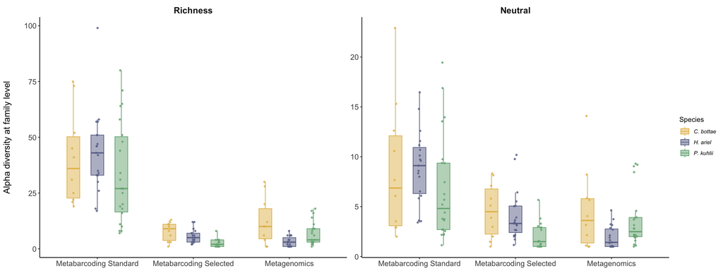

```r
alpha_div_family_data %>%
  select(-sample, -Life_stage, -Sex) %>%
  pivot_longer(
    cols = -c(method, Species),
    names_to = "metric",
    values_to = "value"
  ) %>%
  mutate(
    metric = factor(
      metric,
      levels = c("richness", "neutral"),
      labels = c("Richness", "Neutral")
    ),
    Species = factor(
      Species,
      levels = c("Eb", "Ha", "Pk"),
      labels = c("C. bottae", "H. ariel", "P. kuhlii")
      ),
    method = factor(
      method,
      levels = c("Metabarcoding_standard", "Metabarcoding_selected", "Metagenomics"),
      labels = c("Metabarcoding Standard", "Metabarcoding Selected", "Metagenomics")
  )) %>%
  ggplot(aes(y = value, x = method, color = Species, fill = Species)) +
  geom_boxplot(
    width = 0.4,
    alpha = 0.5,
    outlier.shape = NA,
 #   show.legend = FALSE,
    position = position_dodge(width = 0.75)
  ) +
  geom_jitter(
    position = position_jitterdodge(jitter.width = 0.1, dodge.width = 0.75),
    size = 1,
    alpha = 0.8,
    show.legend = FALSE
  ) +
  facet_wrap(~metric, scales = "free_y") +
  scale_color_manual(values=species_color,  labels = c(expression(italic("C. bottae")),
             expression(italic("H. ariel")),
             expression(italic("P. kuhlii"))))+
  scale_fill_manual(values=species_color,  labels = c(expression(italic("C. bottae")),
             expression(italic("H. ariel")),
             expression(italic("P. kuhlii")))) +
  theme_classic() +
  theme(
    strip.background = element_blank(),
    panel.grid.minor.x = element_line(size = 0.1, color = "grey"),
    axis.text.y = element_text(size = 12),
    axis.text.x = element_text(size = 12),
    axis.title.x = element_blank(),
    axis.title.y = element_text(margin = margin(t = 0, r = 20, b = 0, l = 0), size = 14),
    strip.text = element_text(size = 14, lineheight = 0.6, face = "bold")
  ) +
  labs(
#    x = "Methodological approach",
    y = "Alpha diversity at family level",
    fill = "Species"
  )
```

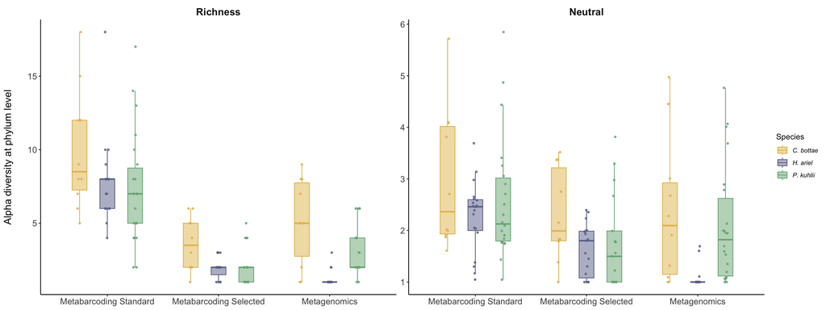

```r
alpha_div_phylum_data %>%
  select(-sample, -Life_stage, -Sex) %>%
  pivot_longer(
    cols = -c(method, Species),
    names_to = "metric",
    values_to = "value"
  ) %>%
  mutate(
    metric = factor(
      metric,
      levels = c("richness", "neutral"),
      labels = c("Richness", "Neutral")
    ),
    Species = factor(
      Species,
      levels = c("Eb", "Ha", "Pk"),
      labels = c("C. bottae", "H. ariel", "P. kuhlii")
      ),
    method = factor(
      method,
      levels = c("Metabarcoding_standard", "Metabarcoding_selected", "Metagenomics"),
      labels = c("Metabarcoding Standard", "Metabarcoding Selected", "Metagenomics")
  )) %>%
  ggplot(aes(y = value, x = method, color = Species, fill = Species)) +
  geom_boxplot(
    width = 0.4,
    alpha = 0.5,
    outlier.shape = NA,
 #   show.legend = FALSE,
    position = position_dodge(width = 0.75)
  ) +
  geom_jitter(
    position = position_jitterdodge(jitter.width = 0.1, dodge.width = 0.75),
    size = 1,
    alpha = 0.8,
    show.legend = FALSE
  ) +
  facet_wrap(~metric, scales = "free_y") +
  scale_color_manual(values=species_color,  labels = c(expression(italic("C. bottae")),
             expression(italic("H. ariel")),
             expression(italic("P. kuhlii"))))+
  scale_fill_manual(values=species_color,  labels = c(expression(italic("C. bottae")),
             expression(italic("H. ariel")),
             expression(italic("P. kuhlii")))) +
  theme_classic() +
  theme(
    strip.background = element_blank(),
    panel.grid.minor.x = element_line(size = 0.1, color = "grey"),
    axis.text.y = element_text(size = 12),
    axis.text.x = element_text(size = 12),
    axis.title.x = element_blank(),
    axis.title.y = element_text(margin = margin(t = 0, r = 20, b = 0, l = 0), size = 14),
    strip.text = element_text(size = 14, lineheight = 0.6, face = "bold")
  ) +
  labs(
#    x = "Methodological approach",
    y = "Alpha diversity at phylum level",
    fill = "Species"
  )
```

## 8.3 Beta diversity

### 8.3.1 At different taxonomic level

```r
beta_q0n <- family_level_agg_ampli %>%
  column_to_rownames(., "family") %>%
  hillpair(., q = 0)

beta_q1n <- family_level_agg_ampli %>%
  column_to_rownames(., "family") %>%
  hillpair(., q = 1)

beta_q0n_phylum <- phylum_level_agg_ampli %>%
  column_to_rownames(., "phylum") %>%
  hillpair(., q = 0)

beta_q1n_phylum <- phylum_level_agg_ampli %>%
  column_to_rownames(., "phylum") %>%
  hillpair(., q = 1)
```

```r
save(beta_q0n,
     beta_q1n,
     beta_q0n_phylum,
     beta_q1n_phylum,
     file = "resources/beta_tax_sele.Rdata")
```

```r
load("resources/beta_tax_sele.Rdata")
```

#### 8.3.1.1 Family

**Richness**

```r
adonis2(
  beta_q0n$S ~ Species,
  by = "terms",
  data = sample_metadata_amplicon %>%
    filter(sample %in% labels(beta_q0n$S)) %>%
    arrange(match(sample, labels(beta_q0n$S))),
  permutations = 999
) %>%
  broom::tidy() %>%
  tt()
```

| term | df | SumOfSqs | R2 | statistic | p.value |
| --- | --- | --- | --- | --- | --- |
| Species | 2 | 1.936832 | 0.1062653 | 2.556355 | 0.001 |
| Residual | 43 | 16.289560 | 0.8937347 | NA | NA |
| Total | 45 | 18.226392 | 1.0000000 | NA | NA |

```r
pairwise.adonis(
  beta_q0n$S,
  sample_metadata_amplicon %>%
    filter(sample %in% labels(beta_q0n$S)) %>%
    arrange(match(sample, labels(beta_q0n$S))) %>%
    pull(Species),
  perm = 999) %>%
  tt()
```

| pairs | Df | SumsOfSqs | F.Model | R2 | p.value | p.adjusted | sig |
| --- | --- | --- | --- | --- | --- | --- | --- |
| Eb vs Ha | 1 | 1.1892164 | 3.212674 | 0.10633532 | 0.001 | 0.003 | * |
| Eb vs Pk | 1 | 0.7483175 | 1.901197 | 0.07067333 | 0.042 | 0.126 |  |
| Ha vs Pk | 1 | 0.9556233 | 2.549407 | 0.06975234 | 0.003 | 0.009 | * |

**Neutral**

```r
adonis2(
  beta_q1n$S ~ Species,
  by = "terms",
  data = sample_metadata_amplicon %>%
    filter(sample %in% labels(beta_q1n$S)) %>%
    arrange(match(sample, labels(beta_q1n$S))),
  permutations = 999
) %>%
  broom::tidy() %>%
  tt()
```

| term | df | SumOfSqs | R2 | statistic | p.value |
| --- | --- | --- | --- | --- | --- |
| Species | 2 | 1.881489 | 0.1062486 | 2.555907 | 0.001 |
| Residual | 43 | 15.826869 | 0.8937514 | NA | NA |
| Total | 45 | 17.708358 | 1.0000000 | NA | NA |

```r
pairwise.adonis(
  beta_q1n$S,
  sample_metadata_amplicon %>%
    filter(sample %in% labels(beta_q1n$S)) %>%
    arrange(match(sample, labels(beta_q1n$S))) %>%
    pull(Species),
  perm = 999) %>%
  tt()
```

| pairs | Df | SumsOfSqs | F.Model | R2 | p.value | p.adjusted | sig |
| --- | --- | --- | --- | --- | --- | --- | --- |
| Eb vs Ha | 1 | 1.3532821 | 3.840951 | 0.12454063 | 0.001 | 0.003 | * |
| Eb vs Pk | 1 | 0.7636118 | 2.006946 | 0.07431220 | 0.049 | 0.147 |  |
| Ha vs Pk | 1 | 0.7412715 | 1.995708 | 0.05544294 | 0.049 | 0.147 |  |

#### 8.3.1.2 Phylum

**Richness**

```r
adonis2(
  beta_q0n_phylum$S ~ Species,
  by = "terms",
  data = sample_metadata_amplicon %>%
    filter(sample %in% labels(beta_q0n_phylum$S)) %>%
    arrange(match(sample, labels(beta_q0n_phylum$S))),
  permutations = 999
) %>%
  broom::tidy() %>%
  tt()
```

| term | df | SumOfSqs | R2 | statistic | p.value |
| --- | --- | --- | --- | --- | --- |
| Species | 2 | 0.7646919 | 0.1095595 | 2.645354 | 0.018 |
| Residual | 43 | 6.2150010 | 0.8904405 | NA | NA |
| Total | 45 | 6.9796930 | 1.0000000 | NA | NA |

```r
pairwise.adonis(
  beta_q0n_phylum$S,
  sample_metadata_amplicon %>%
    filter(sample %in% labels(beta_q0n_phylum$S)) %>%
    arrange(match(sample, labels(beta_q0n_phylum$S))) %>%
    pull(Species),
  perm = 999) %>%
  tt()
```

| pairs | Df | SumsOfSqs | F.Model | R2 | p.value | p.adjusted | sig |
| --- | --- | --- | --- | --- | --- | --- | --- |
| Eb vs Ha | 1 | 0.4237598 | 3.707872 | 0.12074662 | 0.017 | 0.051 |  |
| Eb vs Pk | 1 | 0.2966148 | 1.614777 | 0.06067220 | 0.182 | 0.546 |  |
| Ha vs Pk | 1 | 0.4132832 | 2.956948 | 0.08001061 | 0.047 | 0.141 |  |

**Neutral**

```r
adonis2(
  beta_q1n_phylum$S ~ Species,
  by = "terms",
  data = sample_metadata_amplicon %>%
    filter(sample %in% labels(beta_q1n_phylum$S)) %>%
    arrange(match(sample, labels(beta_q1n_phylum$S))),
  permutations = 999
) %>%
  broom::tidy() %>%
  tt()
```

| term | df | SumOfSqs | R2 | statistic | p.value |
| --- | --- | --- | --- | --- | --- |
| Species | 2 | 0.4130198 | 0.07992329 | 1.867617 | 0.164 |
| Residual | 43 | 4.7546835 | 0.92007671 | NA | NA |
| Total | 45 | 5.1677033 | 1.00000000 | NA | NA |

```r
pairwise.adonis(
  beta_q1n_phylum$S,
  sample_metadata_amplicon %>%
    filter(sample %in% labels(beta_q1n_phylum$S)) %>%
    arrange(match(sample, labels(beta_q1n_phylum$S))) %>%
    pull(Species),
  perm = 999) %>%
  tt()
```

| pairs | Df | SumsOfSqs | F.Model | R2 | p.value | p.adjusted | sig |
| --- | --- | --- | --- | --- | --- | --- | --- |
| Eb vs Ha | 1 | 0.1124825 | 1.557418 | 0.05453638 | 0.203 | 0.609 |  |
| Eb vs Pk | 1 | 0.1735256 | 1.121532 | 0.04293514 | 0.322 | 0.966 |  |
| Ha vs Pk | 1 | 0.3069925 | 2.827677 | 0.07678131 | 0.104 | 0.312 |  |

### 8.3.2 Comparison between metabarcoding selected and metagenomics

```r
beta_q0n <- merged_table_family_methods %>%
  select(-H19, -H20) %>%
  column_to_rownames(., "family") %>%
  hillpair(., q = 0)

beta_q1n <- merged_table_family_methods %>%
  select(-H19) %>%
  column_to_rownames(., "family") %>%
  hillpair(., q = 1)

beta_q0n_phylum <- merged_table_phylum_methods %>%
  select(-H19, -H20) %>%
  column_to_rownames(., "phylum") %>%
  hillpair(., q = 0)

beta_q1n_phylum <- merged_table_phylum_methods %>%
  select(-H19) %>%
  column_to_rownames(., "phylum") %>%
  hillpair(., q = 1)
```

```r
save(beta_q0n,
     beta_q1n,
     beta_q0n_phylum,
     beta_q1n_phylum,
     file = "resources/beta_tax.Rdata")
```

```r
load("resources/beta_tax.Rdata")
methods_colors <- c("#d15aa9","#d4b9ed", "#c7c5c6")
```

#### 8.3.2.1 Family level

**Richness**

```r
m <- as.matrix(beta_q0n$S)
samples <- rownames(m)
to_remove <- grepl("_ampli$", samples) & !grepl("_ampli_Select$", samples)
m_filtered <- m[!to_remove, !to_remove]
beta_q0n_S_filtered <- as.dist(m_filtered)


betadisper(beta_q0n_S_filtered, all_samples %>% filter(sample %in% labels(beta_q0n_S_filtered)) %>% arrange(match(sample, labels(beta_q0n_S_filtered))) %>% pull(Species)) %>% permutest(.)
```

```
Permutation test for homogeneity of multivariate dispersions
Permutation: free
Number of permutations: 999

Response: Distances
          Df Sum Sq   Mean Sq      F N.Perm Pr(>F)
Groups     2 0.0253 0.0126481 3.6104    999  0.041 *
Residuals 92 0.3223 0.0035032
---
Signif. codes:  0 '***' 0.001 '**' 0.01 '*' 0.05 '.' 0.1 ' ' 1
```

```r
adonis2(beta_q0n_S_filtered ~ Species*method, data = all_samples %>% filter(sample %in% labels(beta_q0n_S_filtered)) %>% arrange(match(sample, labels(beta_q0n_S_filtered))), permutations = 999) %>%
  broom::tidy() %>%
  tt()
```

| term | df | SumOfSqs | R2 | statistic | p.value |
| --- | --- | --- | --- | --- | --- |
| Model | 5 | 6.444711 | 0.162343 | 3.449748 | 0.001 |
| Residual | 89 | 33.253404 | 0.837657 | NA | NA |
| Total | 94 | 39.698115 | 1.000000 | NA | NA |

```r
adonis2(
  beta_q0n_S_filtered ~ Species*method,
  by = "terms",
  data = all_samples %>%
    filter(sample %in% labels(beta_q0n_S_filtered)) %>%
    arrange(match(sample, labels(beta_q0n_S_filtered))),
  permutations = 999
) %>%
  broom::tidy() %>%
  tt()
```

| term | df | SumOfSqs | R2 | statistic | p.value |
| --- | --- | --- | --- | --- | --- |
| Species | 2 | 2.648151 | 0.06670721 | 3.543779 | 0.001 |
| method | 1 | 2.517837 | 0.06342460 | 6.738783 | 0.001 |
| Species:method | 2 | 1.278723 | 0.03221118 | 1.711199 | 0.005 |
| Residual | 89 | 33.253404 | 0.83765701 | NA | NA |
| Total | 94 | 39.698115 | 1.00000000 | NA | NA |

**Neutral**

```r
m <- as.matrix(beta_q1n$S)
samples <- rownames(m)
to_remove <- grepl("_ampli$", samples) & !grepl("_ampli_Select$", samples)
m_filtered <- m[!to_remove, !to_remove]
beta_q1n_S_filtered <- as.dist(m_filtered)


betadisper(beta_q1n_S_filtered, all_samples %>% filter(sample %in% labels(beta_q1n_S_filtered)) %>% arrange(match(sample, labels(beta_q1n_S_filtered))) %>% pull(Species)) %>% permutest(.)
```

```
Permutation test for homogeneity of multivariate dispersions
Permutation: free
Number of permutations: 999

Response: Distances
          Df  Sum Sq  Mean Sq      F N.Perm Pr(>F)
Groups     2 0.10823 0.054114 5.9591    999  0.002 **
Residuals 93 0.84453 0.009081
---
Signif. codes:  0 '***' 0.001 '**' 0.01 '*' 0.05 '.' 0.1 ' ' 1
```

```r
adonis2(beta_q1n_S_filtered ~ Species*method, data = all_samples %>% filter(sample %in% labels(beta_q1n_S_filtered)) %>% arrange(match(sample, labels(beta_q1n_S_filtered))), permutations = 999) %>%
  broom::tidy() %>%
  tt()
```

| term | df | SumOfSqs | R2 | statistic | p.value |
| --- | --- | --- | --- | --- | --- |
| Model | 5 | 5.612085 | 0.141896 | 2.976479 | 0.001 |
| Residual | 90 | 33.938601 | 0.858104 | NA | NA |
| Total | 95 | 39.550686 | 1.000000 | NA | NA |

```r
adonis2(
  beta_q1n_S_filtered ~ Species*method,
  by = "terms",
  data = all_samples %>%
    filter(sample %in% labels(beta_q1n_S_filtered)) %>%
    arrange(match(sample, labels(beta_q1n_S_filtered))),
  permutations = 999
) %>%
  broom::tidy() %>%
  tt()
```

| term | df | SumOfSqs | R2 | statistic | p.value |
| --- | --- | --- | --- | --- | --- |
| Species | 2 | 2.8205988 | 0.07131605 | 3.7398991 | 0.001 |
| method | 1 | 2.0914729 | 0.05288083 | 5.5462676 | 0.001 |
| Species:method | 2 | 0.7000129 | 0.01769913 | 0.9281638 | 0.555 |
| Residual | 90 | 33.9386014 | 0.85810399 | NA | NA |
| Total | 95 | 39.5506860 | 1.00000000 | NA | NA |

#### 8.3.2.2 Phylum level

**Richness**

```r
m <- as.matrix(beta_q0n_phylum$S)
samples <- rownames(m)
to_remove <- grepl("_ampli$", samples) & !grepl("_ampli_Select$", samples)
m_filtered <- m[!to_remove, !to_remove]
beta_q0n_phylum_S_filtered <- as.dist(m_filtered)


betadisper(beta_q0n_phylum_S_filtered, all_samples %>% filter(sample %in% labels(beta_q0n_phylum_S_filtered)) %>% arrange(match(sample, labels(beta_q0n_phylum_S_filtered))) %>% pull(Species)) %>% permutest(.)
```

```
Permutation test for homogeneity of multivariate dispersions
Permutation: free
Number of permutations: 999

Response: Distances
          Df Sum Sq  Mean Sq      F N.Perm Pr(>F)
Groups     2 0.2333 0.116640 1.6317    999  0.213
Residuals 92 6.5764 0.071482
```

```r
adonis2(beta_q0n_phylum_S_filtered ~ Species*method, data = all_samples %>% filter(sample %in% labels(beta_q0n_phylum_S_filtered)) %>% arrange(match(sample, labels(beta_q0n_phylum_S_filtered))), permutations = 999) %>%
  broom::tidy() %>%
  tt()
```

| term | df | SumOfSqs | R2 | statistic | p.value |
| --- | --- | --- | --- | --- | --- |
| Model | 5 | 4.848799 | 0.2864865 | 7.146968 | 0.001 |
| Residual | 89 | 12.076256 | 0.7135135 | NA | NA |
| Total | 94 | 16.925056 | 1.0000000 | NA | NA |

```r
adonis2(
  beta_q0n_phylum_S_filtered ~ Species*method,
  by = "terms",
  data = all_samples %>%
    filter(sample %in% labels(beta_q0n_phylum_S_filtered)) %>%
    arrange(match(sample, labels(beta_q0n_phylum_S_filtered))),
  permutations = 999
) %>%
  broom::tidy() %>%
  tt()
```

| term | df | SumOfSqs | R2 | statistic | p.value |
| --- | --- | --- | --- | --- | --- |
| Species | 2 | 2.7746936 | 0.16394000 | 10.224515 | 0.001 |
| method | 1 | 1.0793787 | 0.06377401 | 7.954842 | 0.001 |
| Species:method | 2 | 0.9947267 | 0.05877244 | 3.665485 | 0.006 |
| Residual | 89 | 12.0762564 | 0.71351355 | NA | NA |
| Total | 94 | 16.9250555 | 1.00000000 | NA | NA |

**Neutral**

```r
m <- as.matrix(beta_q1n_phylum$S)
samples <- rownames(m)
to_remove <- grepl("_ampli$", samples) & !grepl("_ampli_Select$", samples)
m_filtered <- m[!to_remove, !to_remove]
beta_q1n_phylum_S_filtered <- as.dist(m_filtered)


betadisper(beta_q1n_phylum_S_filtered, all_samples %>% filter(sample %in% labels(beta_q1n_phylum_S_filtered)) %>% arrange(match(sample, labels(beta_q1n_phylum_S_filtered))) %>% pull(Species)) %>% permutest(.)
```

```
Permutation test for homogeneity of multivariate dispersions
Permutation: free
Number of permutations: 999

Response: Distances
          Df Sum Sq  Mean Sq      F N.Perm Pr(>F)
Groups     2 0.4308 0.215395 2.9832    999  0.063 .
Residuals 93 6.7149 0.072203
---
Signif. codes:  0 '***' 0.001 '**' 0.01 '*' 0.05 '.' 0.1 ' ' 1
```

```r
adonis2(beta_q1n_phylum_S_filtered ~ Species*method, data = all_samples %>% filter(sample %in% labels(beta_q1n_phylum_S_filtered)) %>% arrange(match(sample, labels(beta_q1n_phylum_S_filtered))), permutations = 999) %>%
  broom::tidy() %>%
  tt()
```

| term | df | SumOfSqs | R2 | statistic | p.value |
| --- | --- | --- | --- | --- | --- |
| Model | 5 | 1.978556 | 0.1572087 | 3.357602 | 0.005 |
| Residual | 90 | 10.606975 | 0.8427913 | NA | NA |
| Total | 95 | 12.585531 | 1.0000000 | NA | NA |

```r
adonis2(
  beta_q1n_phylum_S_filtered ~ Species*method,
  by = "terms",
  data = all_samples %>%
    filter(sample %in% labels(beta_q1n_phylum_S_filtered)) %>%
    arrange(match(sample, labels(beta_q1n_phylum_S_filtered))),
  permutations = 999
) %>%
  broom::tidy() %>%
  tt()
```

| term | df | SumOfSqs | R2 | statistic | p.value |
| --- | --- | --- | --- | --- | --- |
| Species | 2 | 1.29254282 | 0.10270070 | 5.4836017 | 0.001 |
| method | 1 | 0.62148101 | 0.04938060 | 5.2732556 | 0.010 |
| Species:method | 2 | 0.06453168 | 0.00512745 | 0.2737751 | 0.856 |
| Residual | 90 | 10.60697513 | 0.84279125 | NA | NA |
| Total | 95 | 12.58553064 | 1.00000000 | NA | NA |

### 8.3.3 Three methodological approaches together

#### 8.3.3.1 Family

**Richness**

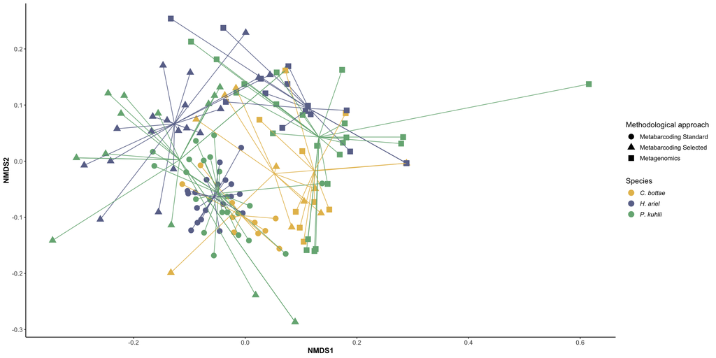

```r
beta_q0n$S %>%
  vegan::metaMDS(.,
                 trymax = 500,
                 k = 2,
                 trace = 0) %>%
  vegan::scores() %>%
  as_tibble(., rownames = "sample") %>%
  dplyr::left_join(all_samples, by = join_by(sample == sample)) %>%
  group_by(method, Species) %>%
  mutate(x_cen = mean(NMDS1, na.rm = TRUE)) %>%
  mutate(y_cen = mean(NMDS2, na.rm = TRUE)) %>%
  ungroup() %>%
  mutate(
    Species = factor(
      Species,
      levels = c("Eb", "Ha", "Pk"),
      labels = c("C. bottae", "H. ariel", "P. kuhlii")),
      method = factor(
      method,
      levels = c("Metabarcoding_standard", "Metabarcoding_selected", "Metagenomics"),
      labels = c("Metabarcoding Standard", "Metabarcoding Selected", "Metagenomics")
      )
  ) %>%
  ggplot(aes(x = NMDS1, y = NMDS2, color = Species, shape=method)) +
  geom_point(size = 4) +
  geom_segment(aes(x = x_cen, y = y_cen, xend = NMDS1, yend = NMDS2 ), alpha = 0.9, show.legend = FALSE) +
  scale_color_manual(values = species_color,
                     labels = c(
                       expression(italic("C. bottae")),
                       expression(italic("H. ariel")),
                       expression(italic("P. kuhlii"))
                     ))+
  theme(
    axis.title = element_text(size = 12, face = "bold"),
    axis.text = element_text(size = 10),
    panel.background = element_blank(),
    axis.line = element_line(
      size = 0.5,
      linetype = "solid",
      colour = "black"
    ),
    legend.text = element_text(size = 10),
    legend.title = element_text(size = 12),
    legend.position = "right",
    legend.box = "vertical"
  ) +
  labs(
    shape = "Methodological approach"
  )#+labs(color = "method") +geom_text_repel(aes(label = sample), size=3)
```

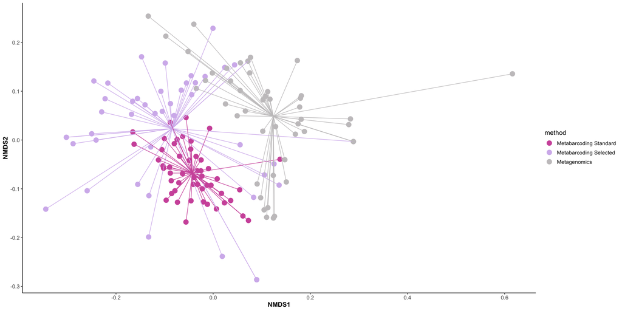

```r
beta_q0n$S %>%
  vegan::metaMDS(.,
                 trymax = 500,
                 k = 2,
                 trace = 0) %>%
  vegan::scores() %>%
  as_tibble(., rownames = "sample") %>%
  dplyr::left_join(all_samples, by = join_by(sample == sample)) %>%
  group_by(method) %>%
  mutate(x_cen = mean(NMDS1, na.rm = TRUE)) %>%
  mutate(y_cen = mean(NMDS2, na.rm = TRUE)) %>%
  ungroup() %>%
  mutate(method = factor(method,
      levels = c("Metabarcoding_standard", "Metabarcoding_selected", "Metagenomics"),
      labels = c("Metabarcoding Standard", "Metabarcoding Selected", "Metagenomics")
      )
  ) %>%
  ggplot(aes(x = NMDS1, y = NMDS2, color = method)) +
  geom_point(size = 4) +
  geom_segment(aes(x = x_cen, y = y_cen, xend = NMDS1, yend = NMDS2 ), alpha = 0.9, show.legend = FALSE) +
  scale_color_manual(values = methods_colors)+
  theme(
    axis.title = element_text(size = 12, face = "bold"),
    axis.text = element_text(size = 10),
    panel.background = element_blank(),
    axis.line = element_line(
      size = 0.5,
      linetype = "solid",
      colour = "black"
    ),
    legend.text = element_text(size = 10),
    legend.title = element_text(size = 12),
    legend.position = "right",
    legend.box = "vertical"
  )
```

**Neutral**

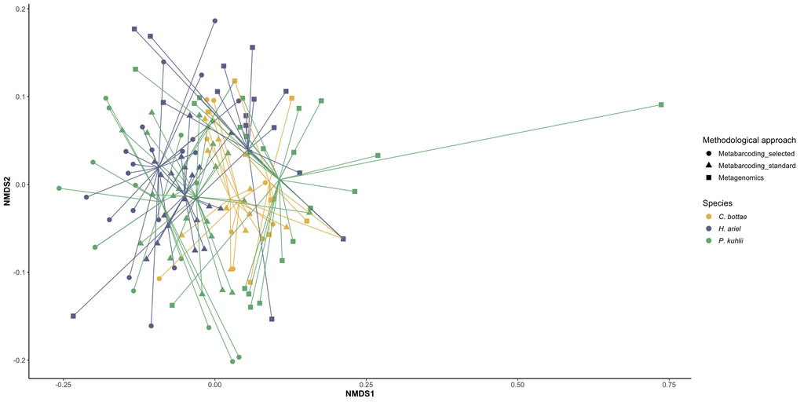

```r
beta_q1n$S %>%
  vegan::metaMDS(.,
                 trymax = 500,
                 k = 2,
                 trace = 0) %>%
  vegan::scores() %>%
  as_tibble(., rownames = "sample") %>%
  dplyr::left_join(all_samples, by = join_by(sample == sample)) %>%
  group_by(method, Species) %>%
  mutate(x_cen = mean(NMDS1, na.rm = TRUE)) %>%
  mutate(y_cen = mean(NMDS2, na.rm = TRUE)) %>%
  ungroup() %>%
  mutate(
    Species = factor(
      Species,
      levels = c("Eb", "Ha", "Pk"),
      labels = c("C. bottae", "H. ariel", "P. kuhlii"))
  ) %>%
  ggplot(aes(x = NMDS1, y = NMDS2, color = Species, shape=method)) +
  geom_point(size = 3) +
  geom_segment(aes(x = x_cen, y = y_cen, xend = NMDS1, yend = NMDS2 ), alpha = 0.9, show.legend = FALSE) +
  scale_color_manual(values = species_color,
                     labels = c(
                       expression(italic("C. bottae")),
                       expression(italic("H. ariel")),
                       expression(italic("P. kuhlii"))
                     ))+
  theme(
    axis.title = element_text(size = 12, face = "bold"),
    axis.text = element_text(size = 10),
    panel.background = element_blank(),
    axis.line = element_line(
      size = 0.5,
      linetype = "solid",
      colour = "black"
    ),
    legend.text = element_text(size = 10),
    legend.title = element_text(size = 12),
    legend.position = "right",
    legend.box = "vertical"
  ) +
  labs(shape = "Methodological approach")
```

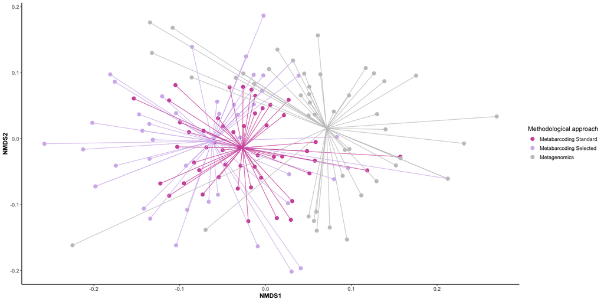

```r
beta_q1n$S %>%
  vegan::metaMDS(.,
                 trymax = 500,
                 k = 2,
                 trace = 0) %>%
  vegan::scores() %>%
  as_tibble(., rownames = "sample") %>%
  dplyr::left_join(all_samples, by = join_by(sample == sample)) %>%
  filter(sample!="P36") %>%
  group_by(method) %>%
  mutate(x_cen = mean(NMDS1, na.rm = TRUE)) %>%
  mutate(y_cen = mean(NMDS2, na.rm = TRUE)) %>%
  ungroup() %>%
    mutate(method = factor(method,
      levels = c("Metabarcoding_standard", "Metabarcoding_selected", "Metagenomics"),
      labels = c("Metabarcoding Standard", "Metabarcoding Selected", "Metagenomics")
      )
  ) %>%
  ggplot(aes(x = NMDS1, y = NMDS2, color = method)) +
  geom_point(size = 3) +
  geom_segment(aes(x = x_cen, y = y_cen, xend = NMDS1, yend = NMDS2 ), alpha = 0.9, show.legend = FALSE) +
  scale_color_manual(values = methods_colors)+
  theme(
    axis.title = element_text(size = 12, face = "bold"),
    axis.text = element_text(size = 10),
    panel.background = element_blank(),
    axis.line = element_line(
      size = 0.5,
      linetype = "solid",
      colour = "black"
    ),
    legend.text = element_text(size = 10),
    legend.title = element_text(size = 12),
    legend.position = "right",
    legend.box = "vertical"
  ) +
  labs(color = "Methodological approach",shape="Species")
```

#### 8.3.3.2 Phylum level

**Richness**

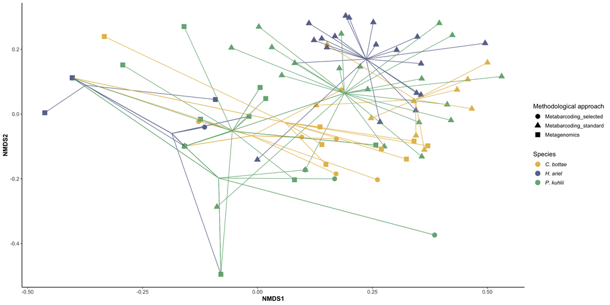

```r
beta_q0n_phylum$S %>%
  vegan::metaMDS(.,
                 trymax = 500,
                 k = 2,
                 trace = 0) %>%
  vegan::scores() %>%
  as_tibble(., rownames = "sample") %>%
  dplyr::left_join(all_samples, by = join_by(sample == sample)) %>%
  group_by(method, Species) %>%
  mutate(x_cen = mean(NMDS1, na.rm = TRUE)) %>%
  mutate(y_cen = mean(NMDS2, na.rm = TRUE)) %>%
  ungroup() %>%
  mutate(
    Species = factor(
      Species,
      levels = c("Eb", "Ha", "Pk"),
      labels = c("C. bottae", "H. ariel", "P. kuhlii"))
  ) %>%
  ggplot(aes(x = NMDS1, y = NMDS2, color = Species, shape=method)) +
  geom_point(size = 4) +
  geom_segment(aes(x = x_cen, y = y_cen, xend = NMDS1, yend = NMDS2 ), alpha = 0.9, show.legend = FALSE) +
  scale_color_manual(values = species_color,
                     labels = c(
                       expression(italic("C. bottae")),
                       expression(italic("H. ariel")),
                       expression(italic("P. kuhlii"))
                     ))+
  theme(
    axis.title = element_text(size = 12, face = "bold"),
    axis.text = element_text(size = 10),
    panel.background = element_blank(),
    axis.line = element_line(
      size = 0.5,
      linetype = "solid",
      colour = "black"
    ),
    legend.text = element_text(size = 10),
    legend.title = element_text(size = 12),
    legend.position = "right",
    legend.box = "vertical"
  ) +
  labs(
    shape = "Methodological approach"
  )
```

**Neutral**

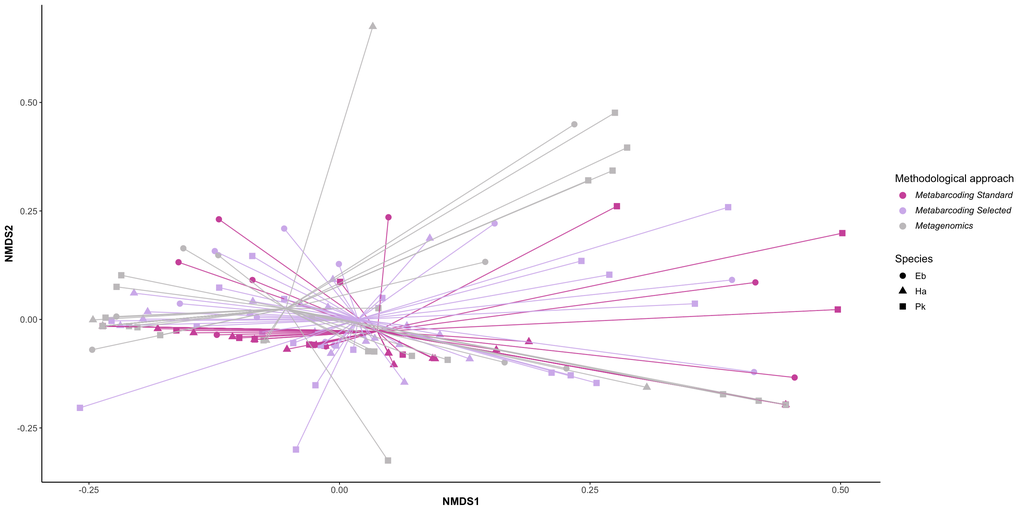

```r
beta_q1n_phylum$S %>%
  vegan::metaMDS(.,
                 trymax = 500,
                 k = 2,
                 trace = 0) %>%
  vegan::scores() %>%
  as_tibble(., rownames = "sample") %>%
  dplyr::left_join(all_samples, by = join_by(sample == sample)) %>%
  group_by(method) %>%
  mutate(x_cen = mean(NMDS1, na.rm = TRUE)) %>%
  mutate(y_cen = mean(NMDS2, na.rm = TRUE)) %>%
  ungroup() %>%
  ggplot(aes(x = NMDS1, y = NMDS2, color = method, shape= Species)) +
  geom_point(size = 3) +
  geom_segment(aes(x = x_cen, y = y_cen, xend = NMDS1, yend = NMDS2 ), alpha = 0.9, show.legend = FALSE) +
  scale_color_manual(values = methods_colors,
                     labels = c(
                       expression(italic("Metabarcoding Standard")),
                       expression(italic("Metabarcoding Selected")),
                       expression(italic("Metagenomics"))
                     ))+
  theme(
    axis.title = element_text(size = 12, face = "bold"),
    axis.text = element_text(size = 10),
    panel.background = element_blank(),
    axis.line = element_line(
      size = 0.5,
      linetype = "solid",
      colour = "black"
    ),
    legend.text = element_text(size = 10),
    legend.title = element_text(size = 12),
    legend.position = "right",
    legend.box = "vertical"
  ) +
  labs(color = "Methodological approach",shape="Species")
```

## 8.4 Differential abundance

### 8.4.1 Metabarcoding selected

```r
load("resources/amplicon/selected_filtering.Rdata")
```

```r
phylo_samples <- sample_metadata_amplicon %>%
  column_to_rownames("sample") %>%
  sample_data()

phylo_genome <- genome_counts_filt_amplicon %>%
  select(one_of(c("genome", rownames(phylo_samples)))) %>%
  column_to_rownames("genome") %>%
  otu_table(., taxa_are_rows = TRUE)

phylo_taxonomy <- genome_metadata_amplicon %>%
  filter(genome %in% rownames(phylo_genome)) %>%
  column_to_rownames("genome") %>%
  dplyr::select(domain,phylum,class,order,family,genus,species) %>%
  as.matrix() %>%
  tax_table()

physeq_genome_metab_sel <- phyloseq(phylo_genome, phylo_samples, phylo_taxonomy)
```

```r
ancom_rand_output_phylum_metab_sel = ancombc2(
  data = physeq_genome_metab_sel,
  assay_name = "counts",
  tax_level = "phylum",
  fix_formula = "Species",
  p_adj_method = "holm",
  pseudo_sens = TRUE,
  prv_cut = 0,
  lib_cut = 0,
  s0_perc = 0.05,
  group = "Species",
  struc_zero = TRUE,
  neg_lb = FALSE,
  alpha = 0.05,
  n_cl = 2,
  verbose = TRUE,
  global = TRUE,
  pairwise = TRUE,
  dunnet = FALSE,
  trend = FALSE,
  iter_control = list(
    tol = 1e-5,
    max_iter = 20,
    verbose = FALSE
  ),
  em_control = list(tol = 1e-5, max_iter = 100),
  mdfdr_control = list(fwer_ctrl_method = "holm", B = 100),
  trend_control = NULL
)
```

#### 8.4.1.1 Structural zeros

*Total number of structural zeros*

```r
# Extract structural zeros
structural_zeros <- ancom_rand_output_phylum_metab_sel$zero_ind

# Convert to a data frame for better readability
structural_zeros_df <- as.data.frame(structural_zeros) %>%
  column_to_rownames(., "taxon")

structural_zero_taxa <- rownames(structural_zeros_df)[apply(structural_zeros_df, 1, any)]

# Identify in which groups each taxon is a structural zero
structural_zero_groups <- structural_zeros_df[structural_zero_taxa, , drop = FALSE] %>%
  rename("Eb"=1) %>%
  rename("Ha"=2) %>%
  rename("Pk"=3)

# Total number of structural zeros
nrow(structural_zero_groups)
```

```
[1] 7
```

#### 8.4.1.2 Enriched data

```r
res_pair_phylum <- ancom_rand_output_phylum_metab_sel$res_pair
# Get log-fold change and q-value columns
lfc_cols <- grep("^lfc_", colnames(res_pair_phylum), value = TRUE)
q_cols   <- gsub("^lfc_", "q_", lfc_cols)

# Build long table by pairing lfc and q for each contrast
plot_data_phylum <- lfc_cols %>%
  setNames(nm = .) %>%
  purrr::imap_dfr(function(lfc_col, name) {
    q_col <- gsub("^lfc_", "q_", lfc_col)

    res_pair_phylum %>%
      select(taxon, !!lfc_col, !!q_col) %>%
      rename(
        lfc = !!lfc_col,
        q   = !!q_col
      ) %>%
      mutate(contrast_key = name)
  }) %>%
  filter(!is.na(lfc), !is.na(q), q < 0.05) %>%
  mutate(
    # Manually re-label contrasts for clarity
    contrast = case_when(
      contrast_key == "lfc_SpeciesHa" ~ "H. ariel vs C. bottae",
      contrast_key == "lfc_SpeciesPk" ~ "P. kuhlii vs C. bottae",
      contrast_key == "lfc_SpeciesPk_SpeciesHa" ~ "P. kuhlii vs H. ariel",
      TRUE ~ contrast_key
    ),
    direction = ifelse(lfc > 0, paste("Enriched in", sub(" vs.*", "", contrast)),
                             paste("Enriched in", sub(".*vs ", "", contrast)))
  )
plot_data_phylum %>% select(-contrast_key)
```

```
[1] taxon     lfc       q         contrast  direction
<0 rows> (or 0-length row.names)
```

### 8.4.2 Differences with metagenomics at phylum level across species

```r
load("resources/amplicon/selected_filtering.Rdata")

sample_metadata_amplicon <- sample_metadata_amplicon[c(1,9,10,13)] %>%
  mutate(sample = paste0(sample, "_ampli")) %>%
  mutate(method="Metabarcoding")

genome_metadata_ampli <- genome_metadata_amplicon %>%
  mutate(
    class  = if_else(is.na(class), paste0(phylum, "_Unclassified"), class),
    order  = if_else(is.na(order),
                     if_else(str_detect(class, "Unclassified"), class, paste0(class, "_Unclassified")),
                     order),
    family = if_else(is.na(family),
                     if_else(str_detect(order, "Unclassified"), order, paste0(order, "_Unclassified")),
                     family),
    genus  = if_else(is.na(genus),
                     if_else(str_detect(family, "Unclassified"), family, paste0(family, "_Unclassified")),
                     genus)
  )

genome_tax_ampli <- genome_counts_filt_amplicon %>%
  column_to_rownames(., "genome")%>%
  rename_with(~ paste0(., "_ampli")) %>%
  rownames_to_column(., "genome")%>%
  left_join(genome_metadata_ampli, by = "genome")

family_level_agg_ampli <- genome_tax_ampli %>%
  select(-genome) %>%
  group_by(phylum, class, family) %>%
  summarise(across(where(is.numeric), \(x) sum(x, na.rm = TRUE)), .groups = "drop")%>%
    as.data.frame() %>%
  select(-c(phylum,class))

phylum_level_agg_ampli <- genome_tax_ampli %>%
  select(-genome) %>%
  group_by(phylum) %>%
  summarise(across(where(is.numeric), \(x) sum(x, na.rm = TRUE)), .groups = "drop")%>%
    as.data.frame()
```

```r
load("resources/metagenomics/data_filtered.Rdata")

genome_metadata <- genome_metadata %>%
  mutate(
    class  = if_else(str_trim(class) == "", paste0(phylum, "_Unclassified"), class),
    order  = if_else(str_trim(order) == "",
                     if_else(str_detect(class, "Unclassified"), class, paste0(class, "_Unclassified")),
                     order),
    family = if_else(str_trim(family) == "",
                     if_else(str_detect(order, "Unclassified"), order, paste0(order, "_Unclassified")),
                     family),
    genus  = if_else(str_trim(genus) == "",
                     if_else(str_detect(family, "Unclassified"), family, paste0(family, "_Unclassified")),
                     genus)
  )

genome_tax <- genome_counts_filt %>%
  left_join(genome_metadata[c(1,3,4,6)], by = "genome")

# Aggregate counts at the Family level
family_level_agg <- genome_tax %>%
  select(-genome) %>%
  group_by(phylum, class, family) %>%
  summarise(across(where(is.numeric), \(x) sum(x, na.rm = TRUE)), .groups = "drop")%>%
  as.data.frame() %>%
  select(-c(phylum,class))

# Aggregate counts at the Phylum level
phylum_level_agg <- genome_tax %>%
  select(-genome) %>%
  group_by(phylum) %>%
  summarise(across(where(is.numeric), \(x) sum(x, na.rm = TRUE)), .groups = "drop")%>%
  as.data.frame()
```

```r
merged_table <- full_join(family_level_agg_ampli,family_level_agg,
          by = c("family"))%>%
  mutate(across(where(is.numeric), ~replace_na(., 0)))

merged_table_phylum <- full_join(phylum_level_agg_ampli,phylum_level_agg,
          by = c("phylum"))%>%
  mutate(across(where(is.numeric), ~replace_na(., 0)))


sample_shot <- sample_metadata %>%
  select(-c(Habitat,Longitude, Latitude, Region))%>%
  mutate(method="Metagenomics")

all_samples <- rbind(sample_shot, sample_metadata_amplicon)
```

```r
phylo_genome <- merged_table_phylum %>%
  column_to_rownames("phylum") %>%
  otu_table(., taxa_are_rows = TRUE)

phylo_samples <- all_samples%>%
  mutate(individual=sample)%>%
  column_to_rownames("sample") %>%
  sample_data()

merged_physeq_phylum <- phyloseq(phylo_genome, phylo_samples)
```

```r
ancom_rand_output_struc_approach_rand = ancombc2(data = merged_physeq_phylum,
                  assay_name = "counts",
                  tax_level = NULL,
                  fix_formula = "method",
                  rand_formula = "(1|Species)",
                  p_adj_method = "holm",
                  pseudo_sens = TRUE,
                  prv_cut =0,
                  lib_cut = 0,
                  s0_perc = 0.05,
                  group = "method",
                  struc_zero = TRUE,
                  neg_lb = FALSE,
                  alpha = 0.05,
                  n_cl = 2,
                  verbose = TRUE,
                  global = FALSE,
                  pairwise = FALSE,
                  dunnet = FALSE,
                  trend = FALSE,
                  iter_control = list(tol = 1e-5, max_iter = 20, verbose = FALSE),
                  em_control = list(tol = 1e-5, max_iter = 100),
                  lme_control = lme4::lmerControl(),
                  mdfdr_control = list(fwer_ctrl_method = "holm", B = 100),
                  trend_control = NULL)
```

*Enriched phyla*

```r
ancom_rand_output_struc_approach_rand$res %>%
  filter(q_methodMetagenomics<0.05) %>%
  tt()
```

| taxon | lfc_(Intercept) | lfc_methodMetagenomics | se_(Intercept) | se_methodMetagenomics | W_(Intercept) | W_methodMetagenomics | p_(Intercept) | p_methodMetagenomics | q_(Intercept) | q_methodMetagenomics | diff_(Intercept) | diff_methodMetagenomics | passed_ss_(Intercept) | passed_ss_methodMetagenomics |
| --- | --- | --- | --- | --- | --- | --- | --- | --- | --- | --- | --- | --- | --- | --- |
| Fusobacteriota | 0.8003038 | -1.780155 | 0.4332382 | 0.5419887 | 1.84726 | -3.284487 | 0.1594676 | 0.005015929 | 0.797338 | 0.0351115 | FALSE | TRUE | FALSE | TRUE |

### 8.4.3 Differences with metagenomics at phylum level within each species

#### 8.4.3.1 Cnephaeus

```r
physeq_eb <- subset_samples(merged_physeq_phylum, Species == "Eb")
physeq_eb <- prune_taxa(taxa_sums(physeq_eb)>0, physeq_eb)
```

```r
ancom_rand_output_struc_eb = ancombc2(data = physeq_eb,
                  assay_name = "counts",
                  tax_level = NULL,
                  fix_formula = "method",
                  p_adj_method = "holm",
                  pseudo_sens = TRUE,
                  prv_cut =0,
                  lib_cut = 0,
                  s0_perc = 0.05,
                  group = "method",
                  struc_zero = TRUE,
                  neg_lb = FALSE,
                  alpha = 0.05,
                  n_cl = 2,
                  verbose = TRUE,
                  global = FALSE,
                  pairwise = FALSE,
                  dunnet = FALSE,
                  trend = FALSE,
                  iter_control = list(tol = 1e-5, max_iter = 20, verbose = FALSE),
                  em_control = list(tol = 1e-5, max_iter = 100),
                  mdfdr_control = list(fwer_ctrl_method = "holm", B = 100),
                  trend_control = NULL)
```

*Total structural zeros*

```r
structural_zeros <- ancom_rand_output_struc_eb$zero_ind

structural_zeros_df <- as.data.frame(structural_zeros) %>%
  column_to_rownames(., "taxon")

structural_zero_taxa <- rownames(structural_zeros_df)[apply(structural_zeros_df, 1, any)]

structural_zero_groups <- structural_zeros_df[structural_zero_taxa, , drop = FALSE] %>%
  rename("amplicon"=1) %>%
  rename("metagenomics"=2)

nrow(structural_zero_groups)
```

```
[1] 5
```

*Structural zeros in amplicon*

```r
structural_zero_groups %>%
  filter(amplicon==TRUE) %>%
  nrow()
```

```
[1] 3
```

```r
structural_zero_groups %>%
  filter(amplicon==TRUE) %>%
  rownames_to_column(., "phylum") %>%
  left_join(., data.frame(physeq_eb@tax_table) %>% rownames_to_column(., "phylum"), by="phylum") %>%
  select(phylum) %>%
  pull()
```

```
[1] "Deferribacterota" "Elusimicrobiota"  "Planctomycetota"
```

*Structural zeros in metagenomics*

```r
structural_zero_groups %>%
  filter(metagenomics==TRUE) %>%
  rownames_to_column(., "phylum") %>%
  left_join(., data.frame(physeq_eb@tax_table) %>% rownames_to_column(., "phylum"), by="phylum") %>%
  select(phylum) %>%
  pull()
```

```
[1] "Patescibacteria"      "Rs-K70 termite group"
```

*Enriched phyla*

```r
ancom_rand_output_struc_eb$res %>%
  filter(q_methodMetagenomics<0.05) %>%
  tt()
```

| taxon | lfc_(Intercept) | lfc_methodMetagenomics | se_(Intercept) | se_methodMetagenomics | W_(Intercept) | W_methodMetagenomics | p_(Intercept) | p_methodMetagenomics | q_(Intercept) | q_methodMetagenomics | diff_(Intercept) | diff_methodMetagenomics | passed_ss_(Intercept) | passed_ss_methodMetagenomics |
| --- | --- | --- | --- | --- | --- | --- | --- | --- | --- | --- | --- | --- | --- | --- |
| Fusobacteriota | 0.8278994 | -1.634606 | 0.1001533 | 0.3561454 | 8.266324 | -4.589716 | 7.390691e-05 | 0.002514619 | 0.0004434415 | 0.01760233 | TRUE | TRUE | FALSE | FALSE |

#### 8.4.3.2 Pipistrellus

```r
physeq_pk <- subset_samples(merged_physeq_phylum, Species == "Pk")
physeq_pk <- prune_taxa(taxa_sums(physeq_pk)>0, physeq_pk)
```

```r
ancom_rand_output_struc_pk = ancombc2(data = physeq_pk,
                  assay_name = "counts",
                  tax_level = NULL,
                  fix_formula = "method",
                  p_adj_method = "holm",
                  pseudo_sens = TRUE,
                  prv_cut =0,
                  lib_cut = 0,
                  s0_perc = 0.05,
                  group = "method",
                  struc_zero = TRUE,
                  neg_lb = FALSE,
                  alpha = 0.05,
                  n_cl = 2,
                  verbose = TRUE,
                  global = FALSE,
                  pairwise = FALSE,
                  dunnet = FALSE,
                  trend = FALSE,
                  iter_control = list(tol = 1e-5, max_iter = 20, verbose = FALSE),
                  em_control = list(tol = 1e-5, max_iter = 100),
                  mdfdr_control = list(fwer_ctrl_method = "holm", B = 100),
                  trend_control = NULL)
```

*Total structural zeros*

```r
structural_zeros <- ancom_rand_output_struc_pk$zero_ind

structural_zeros_df <- as.data.frame(structural_zeros) %>%
  column_to_rownames(., "taxon")

structural_zero_taxa <- rownames(structural_zeros_df)[apply(structural_zeros_df, 1, any)]

structural_zero_groups <- structural_zeros_df[structural_zero_taxa, , drop = FALSE] %>%
  rename("amplicon"=1) %>%
  rename("metagenomics"=2)

nrow(structural_zero_groups)
```

```
[1] 5
```

*Structural zeros in amplicon*

```r
structural_zero_groups %>%
  filter(amplicon==TRUE) %>%
  nrow()
```

```
[1] 4
```

```r
structural_zero_groups %>%
  filter(amplicon==TRUE) %>%
  rownames_to_column(., "phylum") %>%
  left_join(., data.frame(physeq_eb@tax_table) %>% rownames_to_column(., "phylum"), by="phylum") %>%
  select(phylum) %>%
  pull()
```

```
[1] "Bacteroidota"     "Campylobacterota" "Synergistota"     "Cyanobacteriota"
```

*Structural zeros in metagenomics*

```r
structural_zero_groups %>%
  filter(metagenomics==TRUE) %>%
  rownames_to_column(., "phylum") %>%
  left_join(., data.frame(physeq_eb@tax_table) %>% rownames_to_column(., "phylum"), by="phylum") %>%
  select(phylum) %>%
  pull()
```

```
[1] "Rs-K70 termite group"
```

*Enriched phyla*

```r
ancom_rand_output_struc_pk$res %>%
  filter(q_methodMetagenomics<0.05) %>%
  tt()
```

| taxon | lfc_(Intercept) | lfc_methodMetagenomics | se_(Intercept) | se_methodMetagenomics | W_(Intercept) | W_methodMetagenomics | p_(Intercept) | p_methodMetagenomics | q_(Intercept) | q_methodMetagenomics | diff_(Intercept) | diff_methodMetagenomics | passed_ss_(Intercept) | passed_ss_methodMetagenomics |
| --- | --- | --- | --- | --- | --- | --- | --- | --- | --- | --- | --- | --- | --- | --- |
| Fusobacteriota | 0.3867639 | -1.578596 | 0.0745789 | 0.2172157 | 5.18597 | -7.267411 | 0.001272495 | 0.0001673939 | 0.002544991 | 0.0006695758 | TRUE | TRUE | FALSE | TRUE |

#### 8.4.3.3 Hypsugo

```r
physeq_ha <- subset_samples(merged_physeq_phylum, Species == "Ha")
physeq_ha <- prune_taxa(taxa_sums(physeq_ha)>0, physeq_ha)
```

```r
ancom_rand_output_struc_ha = ancombc2(data = physeq_ha,
                  assay_name = "counts",
                  tax_level = NULL,
                  fix_formula = "method",
                  p_adj_method = "holm",
                  pseudo_sens = TRUE,
                  prv_cut =0,
                  lib_cut = 0,
                  s0_perc = 0.05,
                  group = "method",
                  struc_zero = TRUE,
                  neg_lb = FALSE,
                  alpha = 0.05,
                  n_cl = 2,
                  verbose = TRUE,
                  global = FALSE,
                  pairwise = FALSE,
                  dunnet = FALSE,
                  trend = FALSE,
                  iter_control = list(tol = 1e-5, max_iter = 20, verbose = FALSE),
                  em_control = list(tol = 1e-5, max_iter = 100),
                  mdfdr_control = list(fwer_ctrl_method = "holm", B = 100),
                  trend_control = NULL)
```

*Total structural zeros*

```r
structural_zeros <- ancom_rand_output_struc_ha$zero_ind

structural_zeros_df <- as.data.frame(structural_zeros) %>%
  column_to_rownames(., "taxon")

structural_zero_taxa <- rownames(structural_zeros_df)[apply(structural_zeros_df, 1, any)]

structural_zero_groups <- structural_zeros_df[structural_zero_taxa, , drop = FALSE] %>%
  rename("amplicon"=1) %>%
  rename("metagenomics"=2)

nrow(structural_zero_groups)
```

```
[1] 3
```

*Structural zeros in amplicon*

```r
structural_zero_groups %>%
  filter(amplicon==TRUE) %>%
  nrow()
```

```
[1] 2
```

```r
structural_zero_groups %>%
  filter(amplicon==TRUE) %>%
  rownames_to_column(., "phylum") %>%
  left_join(., data.frame(physeq_eb@tax_table) %>% rownames_to_column(., "phylum"), by="phylum") %>%
  select(phylum) %>%
  pull()
```

```
[1] "Actinomycetota" "Spirochaetota"
```

*Structural zeros in metagenomics*

```r
structural_zero_groups %>%
  filter(metagenomics==TRUE) %>%
  rownames_to_column(., "phylum") %>%
  left_join(., data.frame(physeq_eb@tax_table) %>% rownames_to_column(., "phylum"), by="phylum") %>%
  select(phylum) %>%
  pull()
```

```
[1] "Campylobacterota"
```

*Enriched phyla*

```r
ancom_rand_output_struc_ha$res %>%
  filter(q_methodMetagenomics<0.05) %>%
  tt()
```

| taxon | lfc_(Intercept) | lfc_methodMetagenomics | se_(Intercept) | se_methodMetagenomics | W_(Intercept) | W_methodMetagenomics | p_(Intercept) | p_methodMetagenomics | q_(Intercept) | q_methodMetagenomics | diff_(Intercept) | diff_methodMetagenomics | passed_ss_(Intercept) | passed_ss_methodMetagenomics |
| --- | --- | --- | --- | --- | --- | --- | --- | --- | --- | --- | --- | --- | --- | --- |
| Bacillota | -1.55506 | 0.7568767 | NA | 0.2493764 | NA | 3.035077 | 1 | 0.008353845 | 1 | 0.02506154 | FALSE | TRUE | FALSE | FALSE |